# ANCOVA in Vocabulario (Vocabulario)

Geiser C. Challco geiser@alumni.usp.br

- Descriptive Statistics of Initial Data
- ANCOVA and Pairwise for one factor: **grupo**
  - Without remove non-normal data
  - Computing ANCOVA and PairWise After removing non-normal data (OK)
    - Plots for ancova
    - Checking linearity assumption
    - Checking normality and homogeneity
- ANCOVA and Pairwise for two factors **grupo:Sexo**
  - Without remove non-normal data
  - Computing ANCOVA and PairWise After removing non-normal data (OK)
    - Plots for ancova
    - Checking linearity assumption
    - Checking normality and homogeneity
- ANCOVA and Pairwise for two factors **grupo:Zona**
  - Without remove non-normal data
  - Computing ANCOVA and PairWise After removing non-normal data (OK)
    - Plots for ancova
    - Checking linearity assumption
    - Checking normality and homogeneity
- ANCOVA and Pairwise for two factors **grupo:Cor.Raca**
  - Without remove non-normal data
  - Computing ANCOVA and PairWise After removing non-normal data (OK)
    - Plots for ancova
    - Checking linearity assumption
    - Checking normality and homogeneity
- ANCOVA and Pairwise for two factors **grupo:Serie**
  - Without remove non-normal data
  - Computing ANCOVA and PairWise After removing non-normal data (OK)
    - Plots for ancova
    - Checking linearity assumption
    - Checking normality and homogeneity
- Summary of Results
  - Descriptive Statistics
  - ANCOVA Table Comparison
  - PairWise Table Comparison
  - EMMS Table Comparison

**NOTE**:

- Teste ANCOVA para determinar se houve diferenças significativas no Vocabulario (medido usando pre- e pos-testes).
- ANCOVA test to determine whether there were significant differences in Vocabulario (measured using pre- and post-tests).

# Descriptive Statistics of Initial Data

```r
df <- get.descriptives(dat, c(dv.pre, dv.pos), c("grupo"),
                       include.global = T, symmetry.test = T, normality.test = F)
df <- plyr::rbind.fill(
  df, do.call(plyr::rbind.fill, lapply(lfatores2, FUN = function(f) {
    if (nrow(dat) > 0 && sum(!is.na(unique(dat[[f]]))) > 1)
      get.descriptives(dat, c(dv.pre,dv.pos), c("grupo", f),
                       symmetry.test = T, normality.test = F)
    }))
)
(df <- df[,c(fatores1[fatores1 %in% colnames(df)],"variable",
             colnames(df)[!colnames(df) %in% c(fatores1,"variable")])])
```

```
##           grupo Sexo   Zona Cor.Raca Serie  variable   n   mean median min max     sd    se    ci   iqr symmetry
## 1      Controle <NA>   <NA>     <NA>  <NA> vocab.pre 108 38.185   37.5  35  45  2.676 0.258 0.510  4.00       NO
## 2  Experimental <NA>   <NA>     <NA>  <NA> vocab.pre 162 38.154   38.0  35  48  2.577 0.202 0.400  4.00       NO
## 3          <NA> <NA>   <NA>     <NA>  <NA> vocab.pre 270 38.167   38.0  35  48  2.612 0.159 0.313  4.00       NO
## 4      Controle <NA>   <NA>     <NA>  <NA> vocab.pos 108 36.389   38.0  10  45  7.148 0.688 1.364  7.00       NO
## 5  Experimental <NA>   <NA>     <NA>  <NA> vocab.pos 162 37.623   38.0  16  47  5.328 0.419 0.827  6.00       NO
## 6          <NA> <NA>   <NA>     <NA>  <NA> vocab.pos 270 37.130   38.0  10  47  6.139 0.374 0.736  6.00       NO
## 7      Controle    F   <NA>     <NA>  <NA> vocab.pre  57 37.965   37.0  35  45  2.618 0.347 0.695  3.00       NO
## 8      Controle    M   <NA>     <NA>  <NA> vocab.pre  51 38.431   39.0  35  45  2.744 0.384 0.772  4.00      YES
## 9  Experimental    F   <NA>     <NA>  <NA> vocab.pre  90 38.178   38.0  35  44  2.424 0.256 0.508  4.00       NO
## 10 Experimental    M   <NA>     <NA>  <NA> vocab.pre  72 38.125   37.0  35  48  2.773 0.327 0.652  4.00       NO
## 11     Controle    F   <NA>     <NA>  <NA> vocab.pos  57 37.158   37.0  10  45  5.870 0.777 1.558  5.00       NO
## 12     Controle    M   <NA>     <NA>  <NA> vocab.pos  51 35.529   38.0  11  45  8.327 1.166 2.342  8.00       NO
## 13 Experimental    F   <NA>     <NA>  <NA> vocab.pos  90 38.089   38.5  16  47  5.025 0.530 1.052  5.00       NO
## 14 Experimental    M   <NA>     <NA>  <NA> vocab.pos  72 37.042   37.0  17  45  5.665 0.668 1.331  6.00       NO
```

[output cut: 98 more lines]

| grupo | Sexo | Zona | Cor.Raca | Serie | variable | n | mean | median | min | max | sd | se | ci | iqr | symmetry | skewness | kurtosis |
| --- | --- | --- | --- | --- | --- | --- | --- | --- | --- | --- | --- | --- | --- | --- | --- | --- | --- |
| Controle |  |  |  |  | vocab.pre | 108 | 38.185 | 37.5 | 35 | 45 | 2.676 | 0.258 | 0.510 | 4.00 | NO | 0.769 | -0.210 |
| Experimental |  |  |  |  | vocab.pre | 162 | 38.154 | 38.0 | 35 | 48 | 2.577 | 0.202 | 0.400 | 4.00 | NO | 0.776 | 0.173 |
|  |  |  |  |  | vocab.pre | 270 | 38.167 | 38.0 | 35 | 48 | 2.612 | 0.159 | 0.313 | 4.00 | NO | 0.778 | 0.034 |
| Controle |  |  |  |  | vocab.pos | 108 | 36.389 | 38.0 | 10 | 45 | 7.148 | 0.688 | 1.364 | 7.00 | NO | -1.870 | 4.061 |
| Experimental |  |  |  |  | vocab.pos | 162 | 37.623 | 38.0 | 16 | 47 | 5.328 | 0.419 | 0.827 | 6.00 | NO | -1.522 | 3.626 |
|  |  |  |  |  | vocab.pos | 270 | 37.130 | 38.0 | 10 | 47 | 6.139 | 0.374 | 0.736 | 6.00 | NO | -1.865 | 4.892 |
| Controle | F |  |  |  | vocab.pre | 57 | 37.965 | 37.0 | 35 | 45 | 2.618 | 0.347 | 0.695 | 3.00 | NO | 1.075 | 0.313 |
| Controle | M |  |  |  | vocab.pre | 51 | 38.431 | 39.0 | 35 | 45 | 2.744 | 0.384 | 0.772 | 4.00 | YES | 0.443 | -0.635 |
| Experimental | F |  |  |  | vocab.pre | 90 | 38.178 | 38.0 | 35 | 44 | 2.424 | 0.256 | 0.508 | 4.00 | NO | 0.543 | -0.707 |
| Experimental | M |  |  |  | vocab.pre | 72 | 38.125 | 37.0 | 35 | 48 | 2.773 | 0.327 | 0.652 | 4.00 | NO | 0.955 | 0.675 |
| Controle | F |  |  |  | vocab.pos | 57 | 37.158 | 37.0 | 10 | 45 | 5.870 | 0.777 | 1.558 | 5.00 | NO | -2.079 | 6.870 |
| Controle | M |  |  |  | vocab.pos | 51 | 35.529 | 38.0 | 11 | 45 | 8.327 | 1.166 | 2.342 | 8.00 | NO | -1.539 | 1.971 |
| Experimental | F |  |  |  | vocab.pos | 90 | 38.089 | 38.5 | 16 | 47 | 5.025 | 0.530 | 1.052 | 5.00 | NO | -1.383 | 3.539 |
| Experimental | M |  |  |  | vocab.pos | 72 | 37.042 | 37.0 | 17 | 45 | 5.665 | 0.668 | 1.331 | 6.00 | NO | -1.578 | 3.248 |
| Controle |  | Rural |  |  | vocab.pre | 43 | 37.465 | 37.0 | 35 | 45 | 2.585 | 0.394 | 0.796 | 4.00 | NO | 1.198 | 1.078 |
| Controle |  | Urbana |  |  | vocab.pre | 28 | 37.679 | 37.0 | 35 | 43 | 2.178 | 0.412 | 0.845 | 2.25 | NO | 0.855 | -0.206 |
| Controle |  |  |  |  | vocab.pre | 37 | 39.405 | 39.0 | 35 | 45 | 2.753 | 0.453 | 0.918 | 5.00 | YES | 0.270 | -0.977 |
| Experimental |  | Rural |  |  | vocab.pre | 56 | 38.286 | 38.0 | 35 | 44 | 2.462 | 0.329 | 0.659 | 3.25 | YES | 0.451 | -0.746 |
| Experimental |  | Urbana |  |  | vocab.pre | 50 | 38.120 | 37.0 | 35 | 48 | 2.811 | 0.398 | 0.799 | 3.00 | NO | 1.230 | 1.345 |
| Experimental |  |  |  |  | vocab.pre | 56 | 38.054 | 37.5 | 35 | 44 | 2.511 | 0.336 | 0.673 | 4.00 | YES | 0.475 | -0.953 |
| Controle |  | Rural |  |  | vocab.pos | 43 | 36.930 | 37.0 | 11 | 45 | 6.606 | 1.007 | 2.033 | 7.00 | NO | -1.672 | 3.974 |
| Controle |  | Urbana |  |  | vocab.pos | 28 | 37.286 | 38.0 | 22 | 45 | 4.446 | 0.840 | 1.724 | 3.50 | NO | -1.129 | 2.841 |
| Controle |  |  |  |  | vocab.pos | 37 | 35.081 | 39.0 | 10 | 44 | 9.133 | 1.501 | 3.045 | 9.00 | NO | -1.520 | 1.468 |
| Experimental |  | Rural |  |  | vocab.pos | 56 | 37.036 | 38.5 | 16 | 46 | 6.904 | 0.923 | 1.849 | 6.25 | NO | -1.542 | 2.177 |
| Experimental |  | Urbana |  |  | vocab.pos | 50 | 38.120 | 38.5 | 26 | 46 | 4.129 | 0.584 | 1.173 | 5.00 | NO | -0.750 | 0.588 |
| Experimental |  |  |  |  | vocab.pos | 56 | 37.768 | 37.5 | 23 | 47 | 4.431 | 0.592 | 1.187 | 6.25 | NO | -0.679 | 1.050 |
| Controle |  |  | Branca |  | vocab.pre | 7 | 39.143 | 38.0 | 36 | 45 | 3.579 | 1.353 | 3.310 | 5.50 | YES | 0.424 | -1.651 |
| Controle |  |  | Indígena |  | vocab.pre | 1 | 41.000 | 41.0 | 41 | 41 |  |  |  | 0.00 | few data | 0.000 | 0.000 |
| Controle |  |  | Parda |  | vocab.pre | 32 | 37.625 | 37.0 | 35 | 45 | 2.311 | 0.408 | 0.833 | 3.00 | NO | 1.069 | 1.266 |
| Controle |  |  |  |  | vocab.pre | 68 | 38.309 | 38.0 | 35 | 45 | 2.728 | 0.331 | 0.660 | 4.00 | NO | 0.640 | -0.570 |
| Experimental |  |  | Branca |  | vocab.pre | 16 | 38.500 | 38.0 | 36 | 41 | 1.713 | 0.428 | 0.913 | 3.00 | YES | 0.149 | -1.395 |
| Experimental |  |  | Parda |  | vocab.pre | 36 | 38.306 | 38.0 | 35 | 44 | 2.628 | 0.438 | 0.889 | 3.25 | NO | 0.622 | -0.645 |
| Experimental |  |  |  |  | vocab.pre | 110 | 38.055 | 37.0 | 35 | 48 | 2.675 | 0.255 | 0.505 | 4.00 | NO | 0.860 | 0.332 |
| Controle |  |  | Branca |  | vocab.pos | 7 | 40.857 | 42.0 | 36 | 45 | 3.388 | 1.280 | 3.133 | 4.50 | YES | -0.248 | -1.727 |
| Controle |  |  | Indígena |  | vocab.pos | 1 | 43.000 | 43.0 | 43 | 43 |  |  |  | 0.00 | few data | 0.000 | 0.000 |
| Controle |  |  | Parda |  | vocab.pos | 32 | 35.812 | 37.0 | 10 | 45 | 7.664 | 1.355 | 2.763 | 6.25 | NO | -1.550 | 2.557 |
| Controle |  |  |  |  | vocab.pos | 68 | 36.103 | 38.0 | 11 | 45 | 7.101 | 0.861 | 1.719 | 6.25 | NO | -1.937 | 4.253 |
| Experimental |  |  | Branca |  | vocab.pos | 16 | 39.750 | 40.0 | 35 | 47 | 3.152 | 0.788 | 1.679 | 4.00 | NO | 0.539 | -0.405 |
| Experimental |  |  | Parda |  | vocab.pos | 36 | 38.222 | 39.0 | 17 | 46 | 5.404 | 0.901 | 1.829 | 6.25 | NO | -1.575 | 4.263 |
| Experimental |  |  |  |  | vocab.pos | 110 | 37.118 | 38.0 | 16 | 46 | 5.490 | 0.523 | 1.037 | 6.00 | NO | -1.460 | 2.920 |
| Controle |  |  |  | 6 ano | vocab.pre | 13 | 37.000 | 37.0 | 35 | 41 | 1.871 | 0.519 | 1.131 | 3.00 | NO | 0.564 | -0.777 |
| Controle |  |  |  | 7 ano | vocab.pre | 23 | 37.652 | 37.0 | 35 | 45 | 2.347 | 0.489 | 1.015 | 1.50 | NO | 1.410 | 2.080 |
| Controle |  |  |  | 8 ano | vocab.pre | 22 | 38.091 | 37.0 | 35 | 45 | 3.022 | 0.644 | 1.340 | 4.50 | NO | 0.648 | -0.808 |
| Controle |  |  |  | 9 ano | vocab.pre | 50 | 38.780 | 38.0 | 35 | 45 | 2.743 | 0.388 | 0.779 | 4.00 | YES | 0.470 | -0.788 |
| Experimental |  |  |  | 6 ano | vocab.pre | 17 | 37.059 | 37.0 | 35 | 43 | 2.076 | 0.503 | 1.067 | 3.00 | NO | 1.189 | 1.338 |
| Experimental |  |  |  | 7 ano | vocab.pre | 35 | 38.229 | 37.0 | 35 | 43 | 2.315 | 0.391 | 0.795 | 2.50 | NO | 0.739 | -0.765 |
| Experimental |  |  |  | 8 ano | vocab.pre | 51 | 37.961 | 38.0 | 35 | 43 | 2.315 | 0.324 | 0.651 | 4.00 | YES | 0.388 | -0.990 |
| Experimental |  |  |  | 9 ano | vocab.pre | 59 | 38.593 | 38.0 | 35 | 48 | 2.983 | 0.388 | 0.777 | 5.00 | NO | 0.692 | -0.025 |
| Controle |  |  |  | 6 ano | vocab.pos | 13 | 36.923 | 37.0 | 33 | 40 | 2.060 | 0.571 | 1.245 | 2.00 | YES | -0.381 | -1.053 |
| Controle |  |  |  | 7 ano | vocab.pos | 23 | 35.130 | 37.0 | 11 | 45 | 7.238 | 1.509 | 3.130 | 4.50 | NO | -1.792 | 3.480 |
| Controle |  |  |  | 8 ano | vocab.pos | 22 | 33.864 | 39.0 | 10 | 45 | 11.141 | 2.375 | 4.940 | 11.00 | NO | -1.114 | -0.210 |
| Controle |  |  |  | 9 ano | vocab.pos | 50 | 37.940 | 39.0 | 22 | 45 | 5.262 | 0.744 | 1.495 | 7.75 | NO | -0.865 | 0.195 |
| Experimental |  |  |  | 6 ano | vocab.pos | 17 | 37.059 | 40.0 | 21 | 43 | 6.057 | 1.469 | 3.114 | 5.00 | NO | -1.338 | 0.764 |
| Experimental |  |  |  | 7 ano | vocab.pos | 35 | 35.914 | 37.0 | 17 | 46 | 5.938 | 1.004 | 2.040 | 4.50 | NO | -1.130 | 1.821 |
| Experimental |  |  |  | 8 ano | vocab.pos | 51 | 37.549 | 38.0 | 16 | 44 | 5.471 | 0.766 | 1.539 | 6.00 | NO | -2.109 | 6.018 |
| Experimental |  |  |  | 9 ano | vocab.pos | 59 | 38.864 | 39.0 | 27 | 47 | 4.333 | 0.564 | 1.129 | 5.00 | NO | -0.596 | 0.137 |

# ANCOVA and Pairwise for one factor: **grupo**

## Without remove non-normal data

```r
pdat = remove_group_data(dat[!is.na(dat[["grupo"]]),], "vocab.pos", "grupo")

pdat.long <- rbind(pdat[,c("id","grupo")], pdat[,c("id","grupo")])
pdat.long[["time"]] <- c(rep("pre", nrow(pdat)), rep("pos", nrow(pdat)))
pdat.long[["time"]] <- factor(pdat.long[["time"]], c("pre","pos"))
pdat.long[["vocab"]] <- c(pdat[["vocab.pre"]], pdat[["vocab.pos"]])

aov = anova_test(pdat, vocab.pos ~ vocab.pre + grupo)
laov[["grupo"]] <- get_anova_table(aov)
```

```r
pwc <- emmeans_test(pdat, vocab.pos ~ grupo, covariate = vocab.pre,
                    p.adjust.method = "bonferroni")
```

```r
pwc.long <- emmeans_test(dplyr::group_by_at(pdat.long, "grupo"),
                          vocab ~ time,
                          p.adjust.method = "bonferroni")
lpwc[["grupo"]] <- plyr::rbind.fill(pwc, pwc.long)
```

```r
ds <- get.descriptives(pdat, "vocab.pos", "grupo", covar = "vocab.pre")
ds <- merge(ds[ds$variable != "vocab.pre",],
            ds[ds$variable == "vocab.pre", !colnames(ds) %in% c("variable")],
            by = "grupo", all.x = T, suffixes = c("", ".vocab.pre"))
ds <- merge(get_emmeans(pwc), ds, by = "grupo", suffixes = c(".emms", ""))
ds <- ds[,c("grupo","n","mean.vocab.pre","se.vocab.pre","mean","se","emmean","se.emms")]

colnames(ds) <- c("grupo", "N", paste0(c("M","SE")," (pre)"),
                  paste0(c("M","SE"), " (unadj)"), paste0(c("M", "SE"), " (adj)"))

lemms[["grupo"]] <- ds
```

## Computing ANCOVA and PairWise After removing non-normal data (OK)

```r
wdat = pdat

res = residuals(lm(vocab.pos ~ vocab.pre + grupo, data = wdat))
non.normal = getNonNormal(res, wdat$id, plimit = 0.05)

wdat = wdat[!wdat$id %in% non.normal,]

wdat.long <- rbind(wdat[,c("id","grupo")], wdat[,c("id","grupo")])
wdat.long[["time"]] <- c(rep("pre", nrow(wdat)), rep("pos", nrow(wdat)))
wdat.long[["time"]] <- factor(wdat.long[["time"]], c("pre","pos"))
wdat.long[["vocab"]] <- c(wdat[["vocab.pre"]], wdat[["vocab.pos"]])

ldat[["grupo"]] = wdat

(non.normal)
```

```
##  [1] "P983"  "P1003" "P2232" "P2207" "P2245" "P3654" "P1966" "P996"  "P976"  "P2861" "P3228" "P916"  "P2394"
## [14] "P1012" "P1865"
```

```r
aov = anova_test(wdat, vocab.pos ~ vocab.pre + grupo)
laov[["grupo"]] <- merge(get_anova_table(aov), laov[["grupo"]], by="Effect", suffixes = c("","'"))

(df = get_anova_table(aov))
```

```
## ANOVA Table (type II tests)
##
##      Effect DFn DFd      F        p p<.05      ges
## 1 vocab.pre   1 252 53.357 3.65e-12     * 0.175000
## 2     grupo   1 252  0.196 6.58e-01       0.000778
```

| Effect | DFn | DFd | F | p | p<.05 | ges |
| --- | --- | --- | --- | --- | --- | --- |
| vocab.pre | 1 | 252 | 53.357 | 0.000 | * | 0.175 |
| grupo | 1 | 252 | 0.196 | 0.658 |  | 0.001 |

| term | .y. | group1 | group2 | df | statistic | p | p.adj | p.adj.signif |
| --- | --- | --- | --- | --- | --- | --- | --- | --- |
| vocab.pre*grupo | vocab.pos | Controle | Experimental | 252 | -0.443 | 0.658 | 0.658 | ns |

```r
pwc.long <- emmeans_test(dplyr::group_by_at(wdat.long, "grupo"),
                         vocab ~ time,
                         p.adjust.method = "bonferroni")
lpwc[["grupo"]] <- merge(plyr::rbind.fill(pwc, pwc.long), lpwc[["grupo"]], by=c("grupo","term",".y.","group1","group2"), suffixes = c("","'"))
```

| grupo | term | .y. | group1 | group2 | df | statistic | p | p.adj | p.adj.signif |
| --- | --- | --- | --- | --- | --- | --- | --- | --- | --- |
| Controle | time | vocab | pre | pos | 506 | 0.084 | 0.933 | 0.933 | ns |
| Experimental | time | vocab | pre | pos | 506 | -0.383 | 0.702 | 0.702 | ns |

```r
ds <- get.descriptives(wdat, "vocab.pos", "grupo", covar = "vocab.pre")
ds <- merge(ds[ds$variable != "vocab.pre",],
            ds[ds$variable == "vocab.pre", !colnames(ds) %in% c("variable")],
            by = "grupo", all.x = T, suffixes = c("", ".vocab.pre"))
ds <- merge(get_emmeans(pwc), ds, by = "grupo", suffixes = c(".emms", ""))
ds <- ds[,c("grupo","n","mean.vocab.pre","se.vocab.pre","mean","se","emmean","se.emms")]

colnames(ds) <- c("grupo", "N", paste0(c("M","SE")," (pre)"),
                  paste0(c("M","SE"), " (unadj)"), paste0(c("M", "SE"), " (adj)"))

lemms[["grupo"]] <- merge(ds, lemms[["grupo"]], by=c("grupo"), suffixes = c("","'"))
```

| grupo | N | M (pre) | SE (pre) | M (unadj) | SE (unadj) | M (adj) | SE (adj) |
| --- | --- | --- | --- | --- | --- | --- | --- |
| Controle | 99 | 38.111 | 0.264 | 38.071 | 0.415 | 38.095 | 0.370 |
| Experimental | 156 | 38.173 | 0.208 | 38.321 | 0.320 | 38.305 | 0.295 |

### Plots for ancova

```r
plots <- oneWayAncovaPlots(
  wdat, "vocab.pos", "grupo", aov, list("grupo"=pwc), addParam = c("mean_se"),
  font.label.size=10, step.increase=0.05, p.label="p.adj",
  subtitle = which(aov$Effect == "grupo"))
```

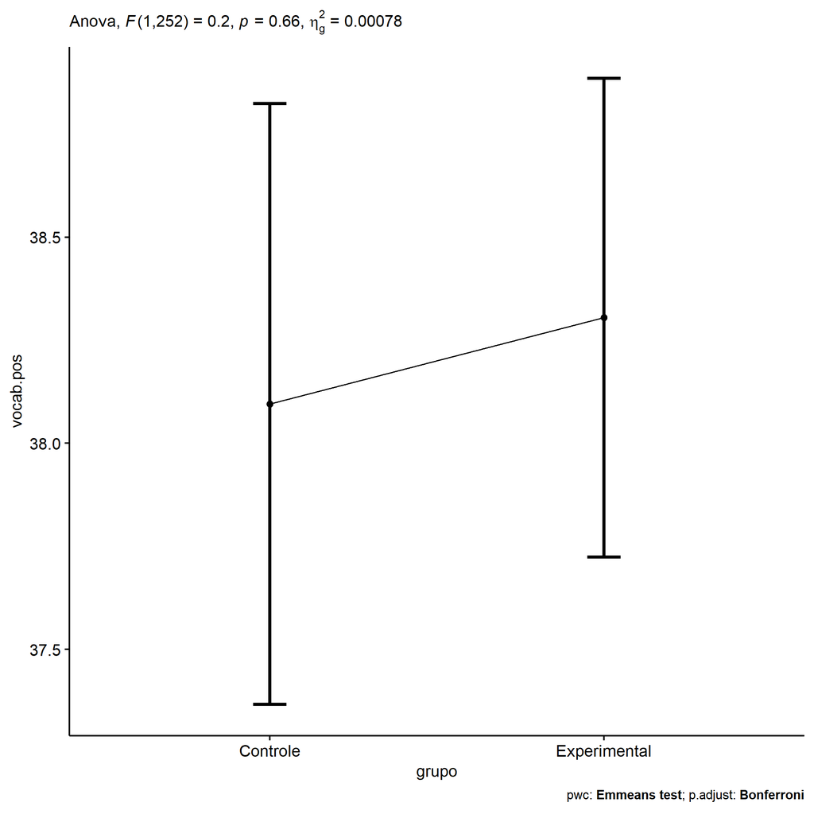

```r
if (!is.null(nrow(plots[["grupo"]]$data)))
  plots[["grupo"]] + ggplot2::scale_color_manual(values = color[["grupo"]])
```

```r
plots <- oneWayAncovaBoxPlots(
  wdat, "vocab.pos", "grupo", aov, pwc, covar = "vocab.pre",
  theme = "classic", color = color[["grupo"]],
  subtitle = which(aov$Effect == "grupo"))
```

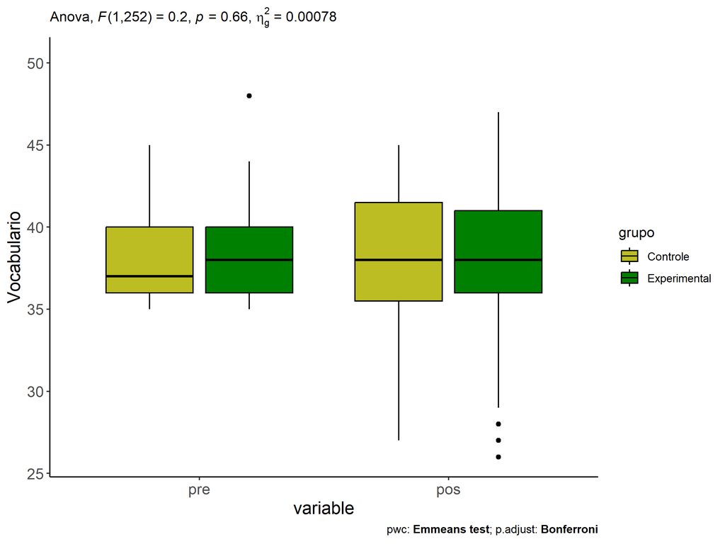

```r
if (length(unique(wdat[["grupo"]])) > 1)
  plots[["grupo"]] + ggplot2::ylab("Vocabulario") + ggplot2::scale_x_discrete(labels=c('pre', 'pos'))
```

```r
if (length(unique(wdat.long[["grupo"]])) > 1)
  plots <- oneWayAncovaBoxPlots(
    wdat.long, "vocab", "grupo", aov, pwc.long, pre.post = "time",
    theme = "classic", color = color$prepost)
```

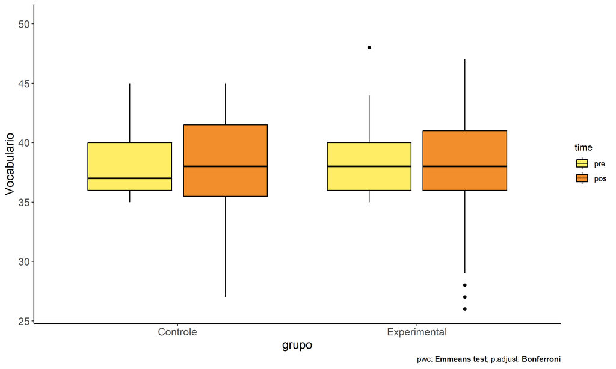

```r
if (length(unique(wdat.long[["grupo"]])) > 1)
  plots[["grupo"]] + ggplot2::ylab("Vocabulario")
```

### Checking linearity assumption

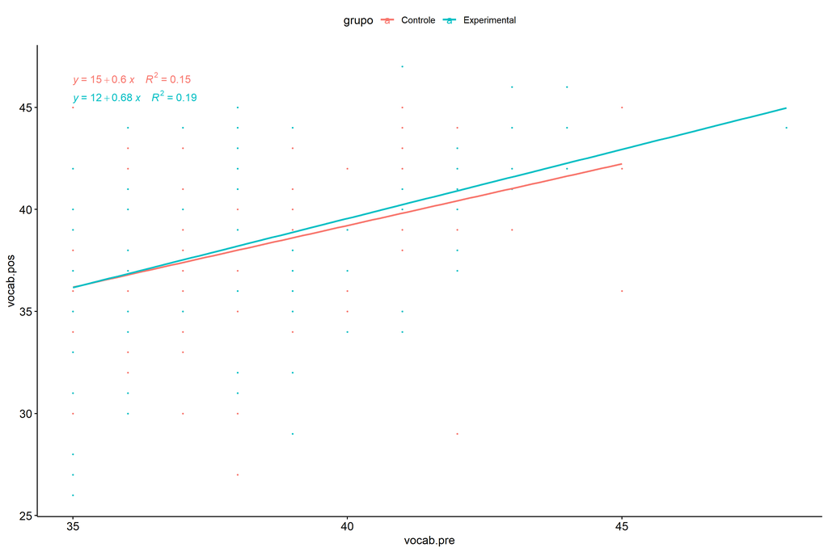

```r
ggscatter(wdat, x = "vocab.pre", y = "vocab.pos", size = 0.5,
          color = "grupo", add = "reg.line")+
  stat_regline_equation(
    aes(label =  paste(..eq.label.., ..rr.label.., sep = "~~~~"), color = grupo)
  )
```

### Checking normality and homogeneity

```r
res <- augment(lm(vocab.pos ~ vocab.pre + grupo, data = wdat))
```

```r
shapiro_test(res$.resid)
```

```
## # A tibble: 1 × 3
##   variable   statistic p.value
##   <chr>          <dbl>   <dbl>
## 1 res$.resid     0.989  0.0467
```

```r
levene_test(res, .resid ~ grupo)
```

```
## # A tibble: 1 × 4
##     df1   df2 statistic     p
##   <int> <int>     <dbl> <dbl>
## 1     1   253     0.125 0.724
```

# ANCOVA and Pairwise for two factors **grupo:Sexo**

## Without remove non-normal data

```r
pdat = remove_group_data(dat[!is.na(dat[["grupo"]]) & !is.na(dat[["Sexo"]]),], "vocab.pos", c("grupo","Sexo"))

pdat.long <- rbind(pdat[,c("id","grupo","Sexo")], pdat[,c("id","grupo","Sexo")])
pdat.long[["time"]] <- c(rep("pre", nrow(pdat)), rep("pos", nrow(pdat)))
pdat.long[["time"]] <- factor(pdat.long[["time"]], c("pre","pos"))
pdat.long[["vocab"]] <- c(pdat[["vocab.pre"]], pdat[["vocab.pos"]])

aov = anova_test(pdat, vocab.pos ~ vocab.pre + grupo*Sexo)
laov[["grupo:Sexo"]] <- get_anova_table(aov)
```

```r
pwcs <- list()
pwcs[["Sexo"]] <- emmeans_test(
  group_by(pdat, grupo), vocab.pos ~ Sexo,
  covariate = vocab.pre, p.adjust.method = "bonferroni")
pwcs[["grupo"]] <- emmeans_test(
  group_by(pdat, Sexo), vocab.pos ~ grupo,
  covariate = vocab.pre, p.adjust.method = "bonferroni")

pwc <- plyr::rbind.fill(pwcs[["grupo"]], pwcs[["Sexo"]])
pwc <- pwc[,c("grupo","Sexo", colnames(pwc)[!colnames(pwc) %in% c("grupo","Sexo")])]
```

```r
pwc.long <- emmeans_test(dplyr::group_by_at(pdat.long, c("grupo","Sexo")),
                         vocab ~ time,
                         p.adjust.method = "bonferroni")
lpwc[["grupo:Sexo"]] <- plyr::rbind.fill(pwc, pwc.long)
```

```r
ds <- get.descriptives(pdat, "vocab.pos", c("grupo","Sexo"), covar = "vocab.pre")
ds <- merge(ds[ds$variable != "vocab.pre",],
            ds[ds$variable == "vocab.pre", !colnames(ds) %in% c("variable")],
            by = c("grupo","Sexo"), all.x = T, suffixes = c("", ".vocab.pre"))
ds <- merge(get_emmeans(pwcs[["grupo"]]), ds, by = c("grupo","Sexo"), suffixes = c(".emms", ""))
ds <- ds[,c("grupo","Sexo","n","mean.vocab.pre","se.vocab.pre","mean","se","emmean","se.emms")]

colnames(ds) <- c("grupo","Sexo", "N", paste0(c("M","SE")," (pre)"),
                  paste0(c("M","SE"), " (unadj)"), paste0(c("M", "SE"), " (adj)"))

lemms[["grupo:Sexo"]] <- ds
```

## Computing ANCOVA and PairWise After removing non-normal data (OK)

```r
wdat = pdat

res = residuals(lm(vocab.pos ~ vocab.pre + grupo*Sexo, data = wdat))
non.normal = getNonNormal(res, wdat$id, plimit = 0.05)

wdat = wdat[!wdat$id %in% non.normal,]

wdat.long <- rbind(wdat[,c("id","grupo","Sexo")], wdat[,c("id","grupo","Sexo")])
wdat.long[["time"]] <- c(rep("pre", nrow(wdat)), rep("pos", nrow(wdat)))
wdat.long[["time"]] <- factor(wdat.long[["time"]], c("pre","pos"))
wdat.long[["vocab"]] <- c(wdat[["vocab.pre"]], wdat[["vocab.pos"]])


ldat[["grupo:Sexo"]] = wdat

(non.normal)
```

```
##  [1] "P1003" "P983"  "P2207" "P2232" "P2245" "P3654" "P1966" "P996"  "P976"  "P2861" "P2394" "P1012" "P916"
## [14] "P3228" "P1865"
```

```r
aov = anova_test(wdat, vocab.pos ~ vocab.pre + grupo*Sexo)
laov[["grupo:Sexo"]] <- merge(get_anova_table(aov), laov[["grupo:Sexo"]], by="Effect", suffixes = c("","'"))

(df = get_anova_table(aov))
```

```
## ANOVA Table (type II tests)
##
##       Effect DFn DFd      F        p p<.05      ges
## 1  vocab.pre   1 250 55.099 1.80e-12     * 0.181000
## 2      grupo   1 250  0.160 6.90e-01       0.000639
## 3       Sexo   1 250  2.256 1.34e-01       0.009000
## 4 grupo:Sexo   1 250  0.415 5.20e-01       0.002000
```

| Effect | DFn | DFd | F | p | p<.05 | ges |
| --- | --- | --- | --- | --- | --- | --- |
| vocab.pre | 1 | 250 | 55.099 | 0.000 | * | 0.181 |
| grupo | 1 | 250 | 0.160 | 0.690 |  | 0.001 |
| Sexo | 1 | 250 | 2.256 | 0.134 |  | 0.009 |
| grupo:Sexo | 1 | 250 | 0.415 | 0.520 |  | 0.002 |

```r
pwcs <- list()
pwcs[["Sexo"]] <- emmeans_test(
  group_by(wdat, grupo), vocab.pos ~ Sexo,
  covariate = vocab.pre, p.adjust.method = "bonferroni")
pwcs[["grupo"]] <- emmeans_test(
  group_by(wdat, Sexo), vocab.pos ~ grupo,
  covariate = vocab.pre, p.adjust.method = "bonferroni")

pwc <- plyr::rbind.fill(pwcs[["grupo"]], pwcs[["Sexo"]])
pwc <- pwc[,c("grupo","Sexo", colnames(pwc)[!colnames(pwc) %in% c("grupo","Sexo")])]
```

| grupo | Sexo | term | .y. | group1 | group2 | df | statistic | p | p.adj | p.adj.signif |
| --- | --- | --- | --- | --- | --- | --- | --- | --- | --- | --- |
|  | F | vocab.pre*grupo | vocab.pos | Controle | Experimental | 250 | 0.139 | 0.889 | 0.889 | ns |
|  | M | vocab.pre*grupo | vocab.pos | Controle | Experimental | 250 | -0.745 | 0.457 | 0.457 | ns |
| Controle |  | vocab.pre*Sexo | vocab.pos | F | M | 250 | 1.440 | 0.151 | 0.151 | ns |
| Experimental |  | vocab.pre*Sexo | vocab.pos | F | M | 250 | 0.773 | 0.440 | 0.440 | ns |

```r
pwc.long <- emmeans_test(dplyr::group_by_at(wdat.long, c("grupo","Sexo")),
                         vocab ~ time,
                         p.adjust.method = "bonferroni")
lpwc[["grupo:Sexo"]] <- merge(plyr::rbind.fill(pwc, pwc.long), lpwc[["grupo:Sexo"]], by=c("grupo","Sexo","term",".y.","group1","group2"), suffixes = c("","'"))
```

| grupo | Sexo | term | .y. | group1 | group2 | df | statistic | p | p.adj | p.adj.signif |
| --- | --- | --- | --- | --- | --- | --- | --- | --- | --- | --- |
| Controle | F | time | vocab | pre | pos | 502 | -0.884 | 0.377 | 0.377 | ns |
| Controle | M | time | vocab | pre | pos | 502 | 1.071 | 0.285 | 0.285 | ns |
| Experimental | F | time | vocab | pre | pos | 502 | -0.686 | 0.493 | 0.493 | ns |
| Experimental | M | time | vocab | pre | pos | 502 | 0.201 | 0.841 | 0.841 | ns |

```r
ds <- get.descriptives(wdat, "vocab.pos", c("grupo","Sexo"), covar = "vocab.pre")
ds <- merge(ds[ds$variable != "vocab.pre",],
            ds[ds$variable == "vocab.pre", !colnames(ds) %in% c("variable")],
            by = c("grupo","Sexo"), all.x = T, suffixes = c("", ".vocab.pre"))
ds <- merge(get_emmeans(pwcs[["grupo"]]), ds, by = c("grupo","Sexo"), suffixes = c(".emms", ""))
ds <- ds[,c("grupo","Sexo","n","mean.vocab.pre","se.vocab.pre","mean","se","emmean","se.emms")]

colnames(ds) <- c("grupo","Sexo", "N", paste0(c("M","SE")," (pre)"),
                  paste0(c("M","SE"), " (unadj)"), paste0(c("M", "SE"), " (adj)"))

lemms[["grupo:Sexo"]] <- merge(ds, lemms[["grupo:Sexo"]], by=c("grupo","Sexo"), suffixes = c("","'"))
```

| grupo | Sexo | N | M (pre) | SE (pre) | M (unadj) | SE (unadj) | M (adj) | SE (adj) |
| --- | --- | --- | --- | --- | --- | --- | --- | --- |
| Controle | F | 53 | 37.736 | 0.332 | 38.321 | 0.495 | 38.594 | 0.506 |
| Controle | M | 46 | 38.543 | 0.413 | 37.783 | 0.690 | 37.522 | 0.543 |
| Experimental | F | 88 | 38.159 | 0.259 | 38.511 | 0.445 | 38.505 | 0.392 |
| Experimental | M | 68 | 38.191 | 0.342 | 38.074 | 0.456 | 38.046 | 0.446 |

### Plots for ancova

```r
plots <- twoWayAncovaPlots(
  wdat, "vocab.pos", c("grupo","Sexo"), aov, pwcs, addParam = c("mean_se"),
  font.label.size=10, step.increase=0.05, p.label="p.adj",
  subtitle = which(aov$Effect == "grupo:Sexo"))
```

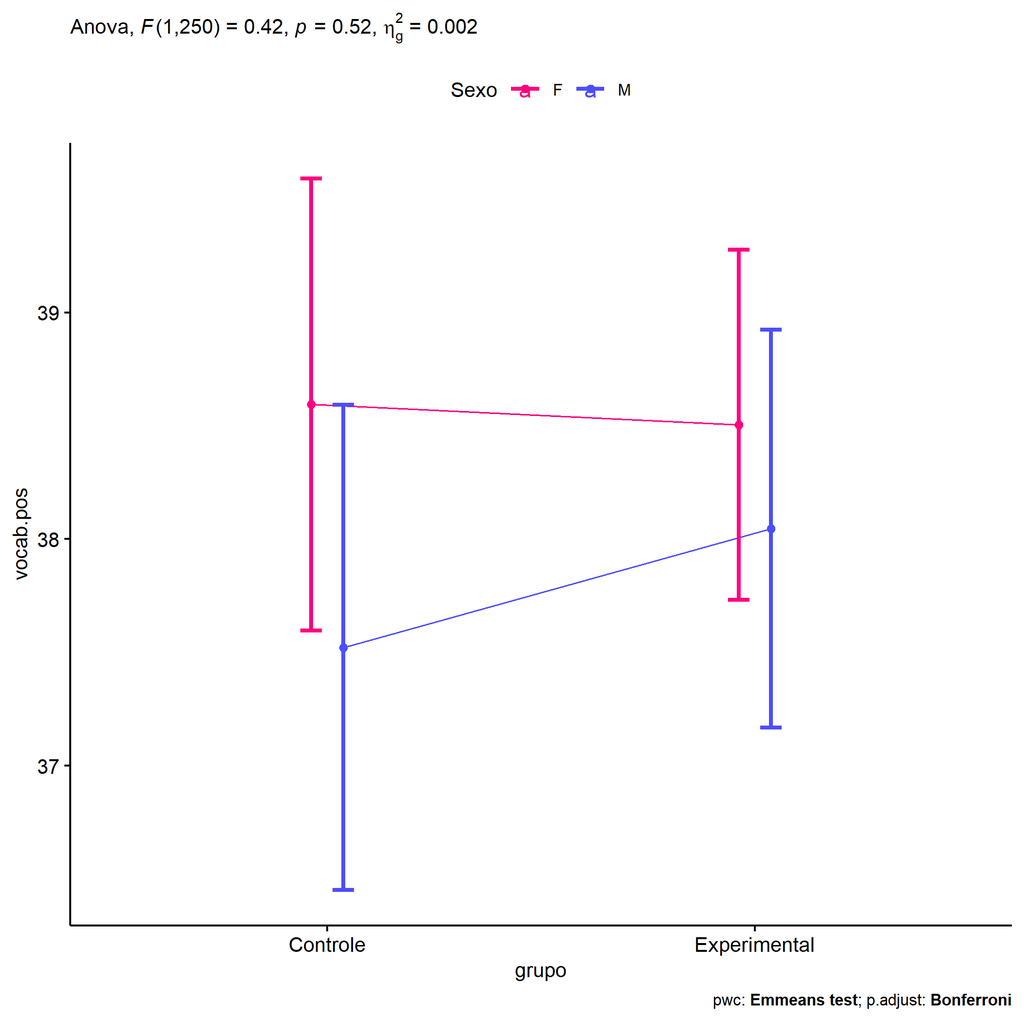

```r
if (!is.null(plots[["grupo"]]))
  plots[["grupo"]] + ggplot2::scale_color_manual(values = color[["Sexo"]])
```

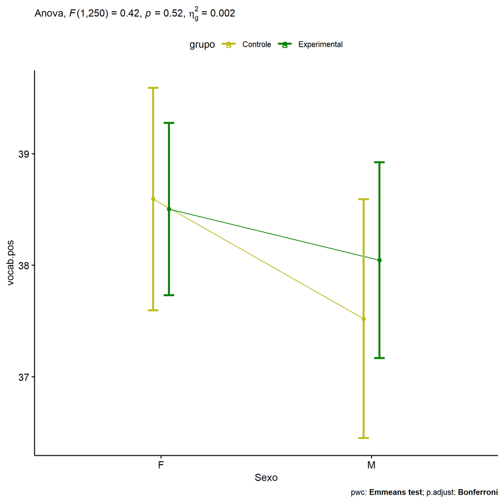

```r
if (!is.null(plots[["Sexo"]]))
  plots[["Sexo"]] + ggplot2::scale_color_manual(values = color[["grupo"]])
```

```r
plots <- twoWayAncovaBoxPlots(
  wdat, "vocab.pos", c("grupo","Sexo"), aov, pwcs, covar = "vocab.pre",
  theme = "classic", color = color[["grupo:Sexo"]],
  subtitle = which(aov$Effect == "grupo:Sexo"))
```

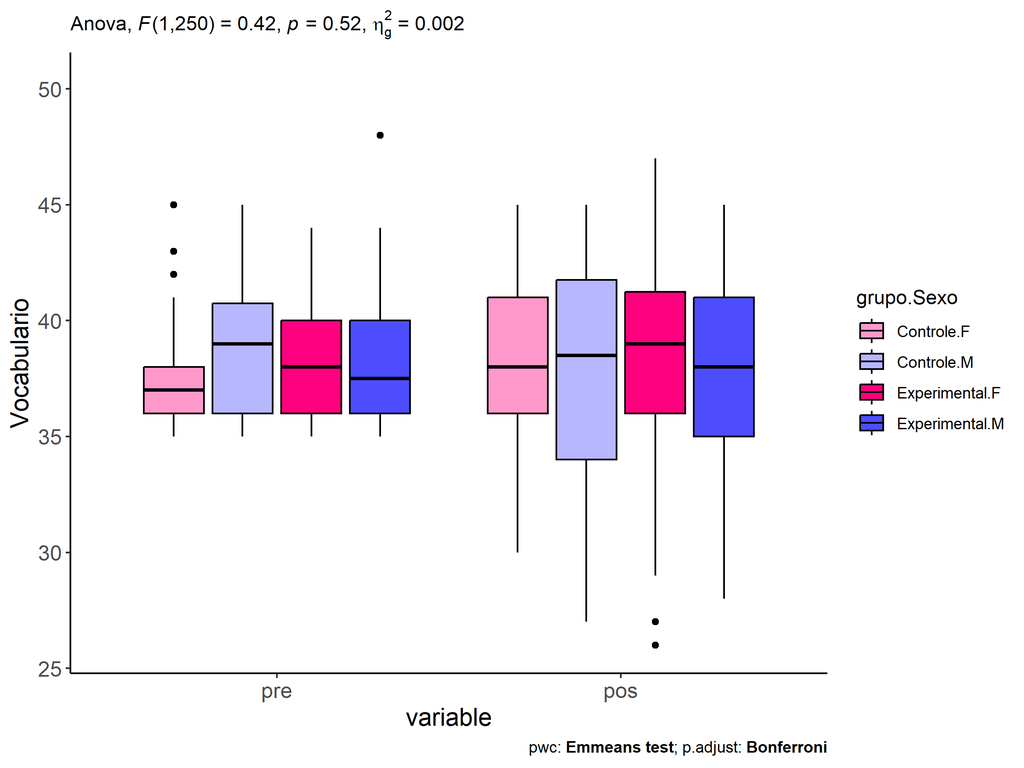

```r
plots[["grupo:Sexo"]] + ggplot2::ylab("Vocabulario") + ggplot2::scale_x_discrete(labels=c('pre', 'pos'))
```

```r
plots <- twoWayAncovaBoxPlots(
  wdat.long, "vocab", c("grupo","Sexo"), aov, pwc.long, pre.post = "time",
  theme = "classic", color = color$prepost)
```

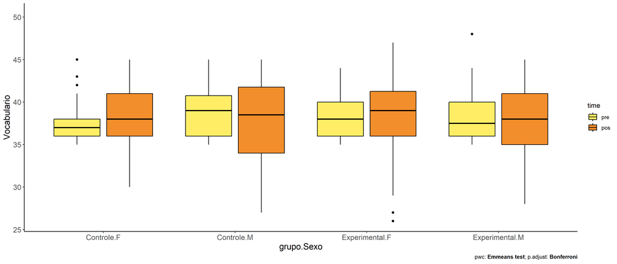

```r
plots[["grupo:Sexo"]] + ggplot2::ylab("Vocabulario")
```

### Checking linearity assumption

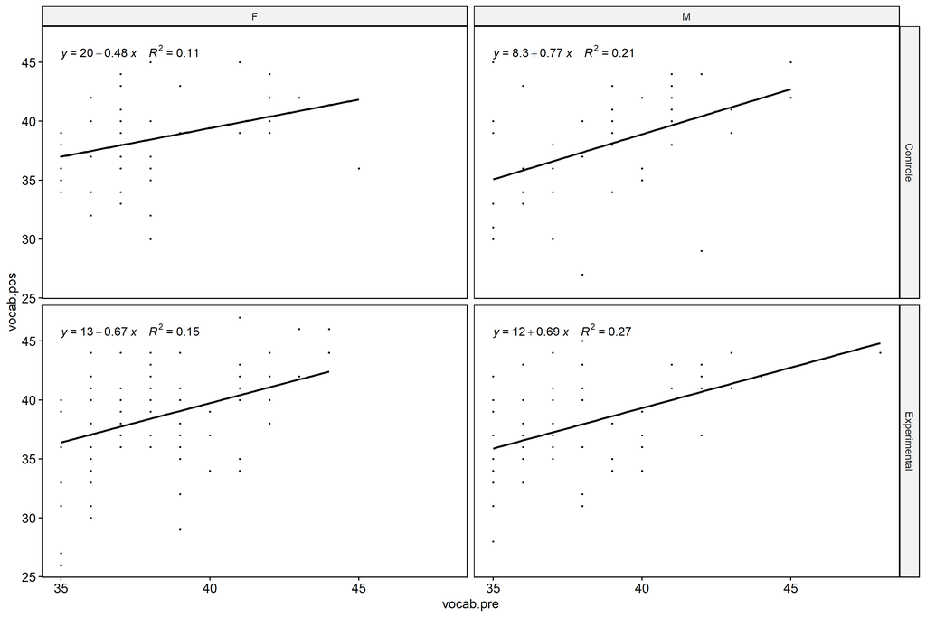

```r
ggscatter(wdat, x = "vocab.pre", y = "vocab.pos", size = 0.5,
          facet.by = c("grupo","Sexo"), add = "reg.line")+
  stat_regline_equation(
    aes(label =  paste(..eq.label.., ..rr.label.., sep = "~~~~"))
  )
```

### Checking normality and homogeneity

```r
res <- augment(lm(vocab.pos ~ vocab.pre + grupo*Sexo, data = wdat))
```

```r
shapiro_test(res$.resid)
```

```
## # A tibble: 1 × 3
##   variable   statistic p.value
##   <chr>          <dbl>   <dbl>
## 1 res$.resid     0.988  0.0388
```

```r
levene_test(res, .resid ~ grupo*Sexo)
```

```
## # A tibble: 1 × 4
##     df1   df2 statistic     p
##   <int> <int>     <dbl> <dbl>
## 1     3   251      1.11 0.344
```

# ANCOVA and Pairwise for two factors **grupo:Zona**

## Without remove non-normal data

```r
pdat = remove_group_data(dat[!is.na(dat[["grupo"]]) & !is.na(dat[["Zona"]]),], "vocab.pos", c("grupo","Zona"))

pdat.long <- rbind(pdat[,c("id","grupo","Zona")], pdat[,c("id","grupo","Zona")])
pdat.long[["time"]] <- c(rep("pre", nrow(pdat)), rep("pos", nrow(pdat)))
pdat.long[["time"]] <- factor(pdat.long[["time"]], c("pre","pos"))
pdat.long[["vocab"]] <- c(pdat[["vocab.pre"]], pdat[["vocab.pos"]])

aov = anova_test(pdat, vocab.pos ~ vocab.pre + grupo*Zona)
laov[["grupo:Zona"]] <- get_anova_table(aov)
```

```r
pwcs <- list()
pwcs[["Zona"]] <- emmeans_test(
  group_by(pdat, grupo), vocab.pos ~ Zona,
  covariate = vocab.pre, p.adjust.method = "bonferroni")
pwcs[["grupo"]] <- emmeans_test(
  group_by(pdat, Zona), vocab.pos ~ grupo,
  covariate = vocab.pre, p.adjust.method = "bonferroni")

pwc <- plyr::rbind.fill(pwcs[["grupo"]], pwcs[["Zona"]])
pwc <- pwc[,c("grupo","Zona", colnames(pwc)[!colnames(pwc) %in% c("grupo","Zona")])]
```

```r
pwc.long <- emmeans_test(dplyr::group_by_at(pdat.long, c("grupo","Zona")),
                         vocab ~ time,
                         p.adjust.method = "bonferroni")
lpwc[["grupo:Zona"]] <- plyr::rbind.fill(pwc, pwc.long)
```

```r
ds <- get.descriptives(pdat, "vocab.pos", c("grupo","Zona"), covar = "vocab.pre")
ds <- merge(ds[ds$variable != "vocab.pre",],
            ds[ds$variable == "vocab.pre", !colnames(ds) %in% c("variable")],
            by = c("grupo","Zona"), all.x = T, suffixes = c("", ".vocab.pre"))
ds <- merge(get_emmeans(pwcs[["grupo"]]), ds, by = c("grupo","Zona"), suffixes = c(".emms", ""))
ds <- ds[,c("grupo","Zona","n","mean.vocab.pre","se.vocab.pre","mean","se","emmean","se.emms")]

colnames(ds) <- c("grupo","Zona", "N", paste0(c("M","SE")," (pre)"),
                  paste0(c("M","SE"), " (unadj)"), paste0(c("M", "SE"), " (adj)"))

lemms[["grupo:Zona"]] <- ds
```

## Computing ANCOVA and PairWise After removing non-normal data (OK)

```r
wdat = pdat

res = residuals(lm(vocab.pos ~ vocab.pre + grupo*Zona, data = wdat))
non.normal = getNonNormal(res, wdat$id, plimit = 0.05)

wdat = wdat[!wdat$id %in% non.normal,]

wdat.long <- rbind(wdat[,c("id","grupo","Zona")], wdat[,c("id","grupo","Zona")])
wdat.long[["time"]] <- c(rep("pre", nrow(wdat)), rep("pos", nrow(wdat)))
wdat.long[["time"]] <- factor(wdat.long[["time"]], c("pre","pos"))
wdat.long[["vocab"]] <- c(wdat[["vocab.pre"]], wdat[["vocab.pos"]])


ldat[["grupo:Zona"]] = wdat

(non.normal)
```

```
## [1] "P983"  "P2207" "P1966" "P3654" "P976"  "P2861" "P3228" "P916"
```

```r
aov = anova_test(wdat, vocab.pos ~ vocab.pre + grupo*Zona)
laov[["grupo:Zona"]] <- merge(get_anova_table(aov), laov[["grupo:Zona"]], by="Effect", suffixes = c("","'"))

(df = get_anova_table(aov))
```

```
## ANOVA Table (type II tests)
##
##       Effect DFn DFd      F        p p<.05      ges
## 1  vocab.pre   1 164 24.719 1.66e-06     * 0.131000
## 2      grupo   1 164  0.106 7.45e-01       0.000647
## 3       Zona   1 164  0.629 4.29e-01       0.004000
## 4 grupo:Zona   1 164  0.059 8.08e-01       0.000362
```

| Effect | DFn | DFd | F | p | p<.05 | ges |
| --- | --- | --- | --- | --- | --- | --- |
| vocab.pre | 1 | 164 | 24.719 | 0.000 | * | 0.131 |
| grupo | 1 | 164 | 0.106 | 0.745 |  | 0.001 |
| Zona | 1 | 164 | 0.629 | 0.429 |  | 0.004 |
| grupo:Zona | 1 | 164 | 0.059 | 0.808 |  | 0.000 |

```r
pwcs <- list()
pwcs[["Zona"]] <- emmeans_test(
  group_by(wdat, grupo), vocab.pos ~ Zona,
  covariate = vocab.pre, p.adjust.method = "bonferroni")
pwcs[["grupo"]] <- emmeans_test(
  group_by(wdat, Zona), vocab.pos ~ grupo,
  covariate = vocab.pre, p.adjust.method = "bonferroni")

pwc <- plyr::rbind.fill(pwcs[["grupo"]], pwcs[["Zona"]])
pwc <- pwc[,c("grupo","Zona", colnames(pwc)[!colnames(pwc) %in% c("grupo","Zona")])]
```

| grupo | Zona | term | .y. | group1 | group2 | df | statistic | p | p.adj | p.adj.signif |
| --- | --- | --- | --- | --- | --- | --- | --- | --- | --- | --- |
|  | Rural | vocab.pre*grupo | vocab.pos | Controle | Experimental | 164 | -0.406 | 0.685 | 0.685 | ns |
|  | Urbana | vocab.pre*grupo | vocab.pos | Controle | Experimental | 164 | -0.035 | 0.972 | 0.972 | ns |
| Controle |  | vocab.pre*Zona | vocab.pos | Rural | Urbana | 164 | 0.306 | 0.760 | 0.760 | ns |
| Experimental |  | vocab.pre*Zona | vocab.pos | Rural | Urbana | 164 | 0.771 | 0.442 | 0.442 | ns |

```r
pwc.long <- emmeans_test(dplyr::group_by_at(wdat.long, c("grupo","Zona")),
                         vocab ~ time,
                         p.adjust.method = "bonferroni")
lpwc[["grupo:Zona"]] <- merge(plyr::rbind.fill(pwc, pwc.long), lpwc[["grupo:Zona"]], by=c("grupo","Zona","term",".y.","group1","group2"), suffixes = c("","'"))
```

| grupo | Zona | term | .y. | group1 | group2 | df | statistic | p | p.adj | p.adj.signif |
| --- | --- | --- | --- | --- | --- | --- | --- | --- | --- | --- |
| Controle | Rural | time | vocab | pre | pos | 330 | -0.747 | 0.456 | 0.456 | ns |
| Controle | Urbana | time | vocab | pre | pos | 330 | -0.160 | 0.873 | 0.873 | ns |
| Experimental | Rural | time | vocab | pre | pos | 330 | -0.728 | 0.467 | 0.467 | ns |
| Experimental | Urbana | time | vocab | pre | pos | 330 | 0.000 | 1.000 | 1.000 | ns |

```r
ds <- get.descriptives(wdat, "vocab.pos", c("grupo","Zona"), covar = "vocab.pre")
ds <- merge(ds[ds$variable != "vocab.pre",],
            ds[ds$variable == "vocab.pre", !colnames(ds) %in% c("variable")],
            by = c("grupo","Zona"), all.x = T, suffixes = c("", ".vocab.pre"))
ds <- merge(get_emmeans(pwcs[["grupo"]]), ds, by = c("grupo","Zona"), suffixes = c(".emms", ""))
ds <- ds[,c("grupo","Zona","n","mean.vocab.pre","se.vocab.pre","mean","se","emmean","se.emms")]

colnames(ds) <- c("grupo","Zona", "N", paste0(c("M","SE")," (pre)"),
                  paste0(c("M","SE"), " (unadj)"), paste0(c("M", "SE"), " (adj)"))

lemms[["grupo:Zona"]] <- merge(ds, lemms[["grupo:Zona"]], by=c("grupo","Zona"), suffixes = c("","'"))
```

| grupo | Zona | N | M (pre) | SE (pre) | M (unadj) | SE (unadj) | M (adj) | SE (adj) |
| --- | --- | --- | --- | --- | --- | --- | --- | --- |
| Controle | Rural | 41 | 37.415 | 0.409 | 37.976 | 0.711 | 38.278 | 0.595 |
| Controle | Urbana | 27 | 37.704 | 0.426 | 37.852 | 0.644 | 37.990 | 0.730 |
| Experimental | Rural | 51 | 38.333 | 0.349 | 38.824 | 0.546 | 38.604 | 0.533 |
| Experimental | Urbana | 50 | 38.120 | 0.398 | 38.120 | 0.584 | 38.021 | 0.537 |

### Plots for ancova

```r
plots <- twoWayAncovaPlots(
  wdat, "vocab.pos", c("grupo","Zona"), aov, pwcs, addParam = c("mean_se"),
  font.label.size=10, step.increase=0.05, p.label="p.adj",
  subtitle = which(aov$Effect == "grupo:Zona"))
```

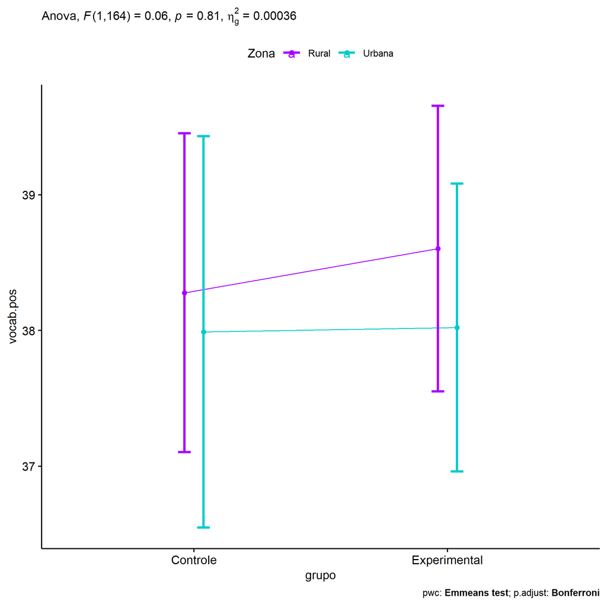

```r
if (!is.null(plots[["grupo"]]))
  plots[["grupo"]] + ggplot2::scale_color_manual(values = color[["Zona"]])
```

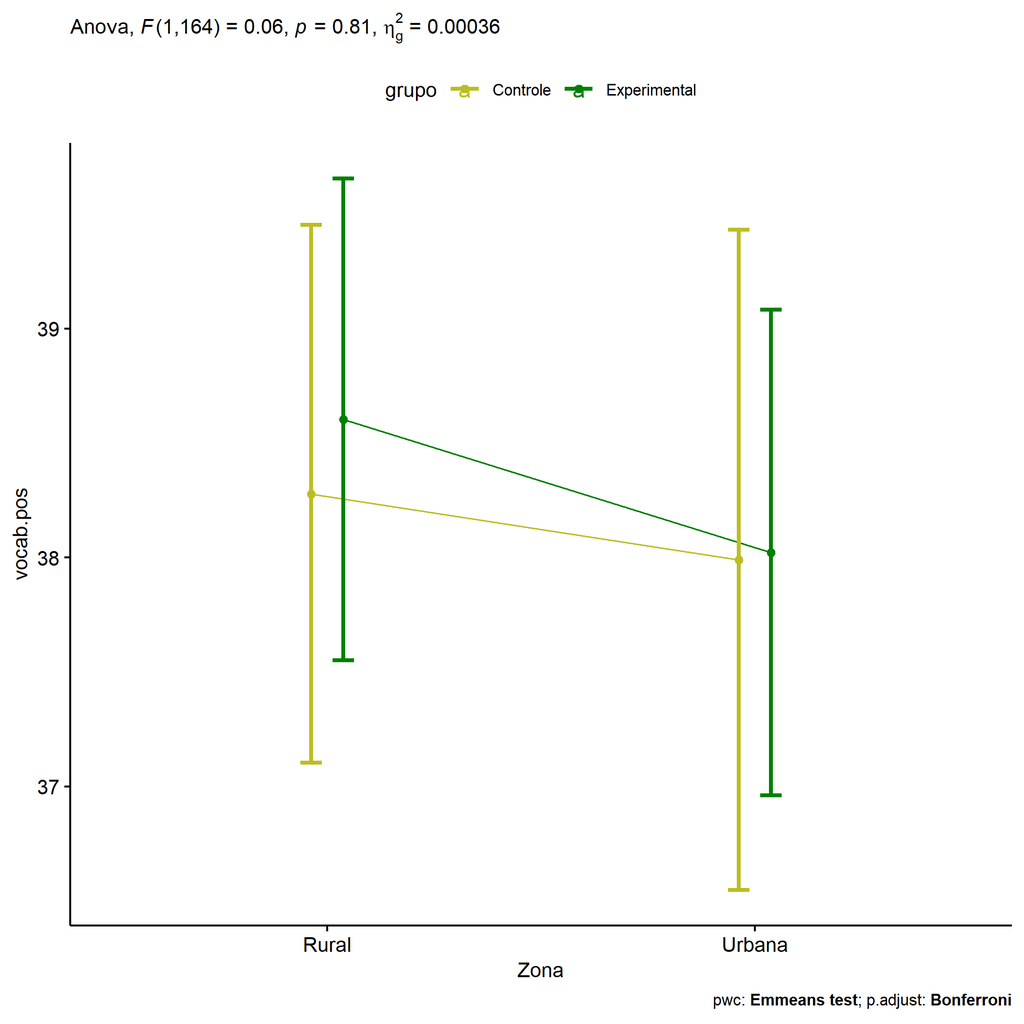

```r
if (!is.null(plots[["Zona"]]))
  plots[["Zona"]] + ggplot2::scale_color_manual(values = color[["grupo"]])
```

```r
plots <- twoWayAncovaBoxPlots(
  wdat, "vocab.pos", c("grupo","Zona"), aov, pwcs, covar = "vocab.pre",
  theme = "classic", color = color[["grupo:Zona"]],
  subtitle = which(aov$Effect == "grupo:Zona"))
```

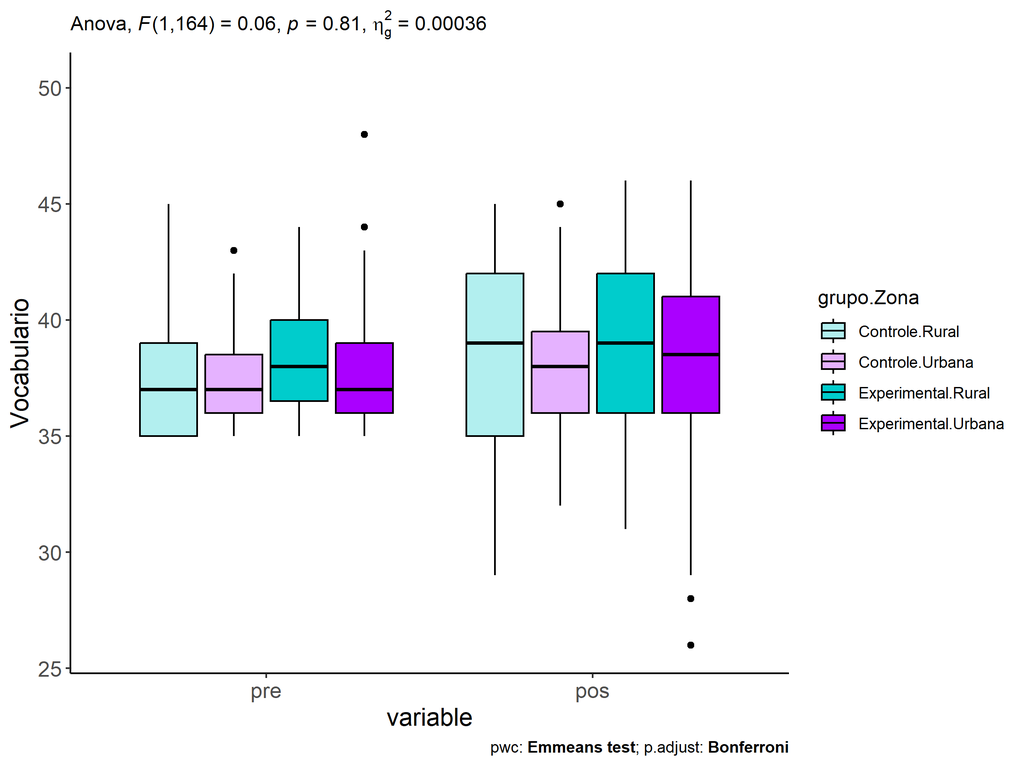

```r
plots[["grupo:Zona"]] + ggplot2::ylab("Vocabulario") + ggplot2::scale_x_discrete(labels=c('pre', 'pos'))
```

```r
plots <- twoWayAncovaBoxPlots(
  wdat.long, "vocab", c("grupo","Zona"), aov, pwc.long, pre.post = "time",
  theme = "classic", color = color$prepost)
```

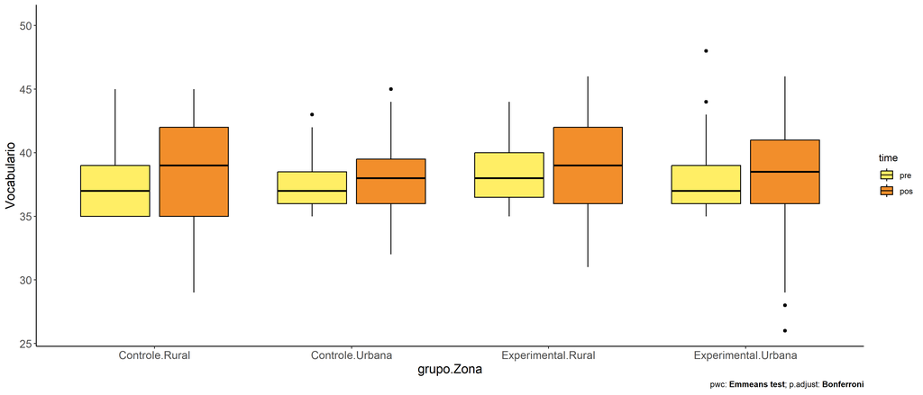

```r
plots[["grupo:Zona"]] + ggplot2::ylab("Vocabulario")
```

### Checking linearity assumption

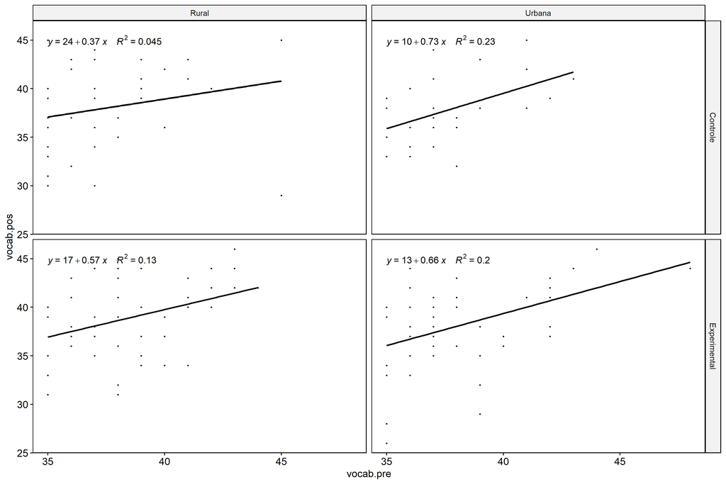

```r
ggscatter(wdat, x = "vocab.pre", y = "vocab.pos", size = 0.5,
          facet.by = c("grupo","Zona"), add = "reg.line")+
  stat_regline_equation(
    aes(label =  paste(..eq.label.., ..rr.label.., sep = "~~~~"))
  )
```

### Checking normality and homogeneity

```r
res <- augment(lm(vocab.pos ~ vocab.pre + grupo*Zona, data = wdat))
```

```r
shapiro_test(res$.resid)
```

```
## # A tibble: 1 × 3
##   variable   statistic p.value
##   <chr>          <dbl>   <dbl>
## 1 res$.resid     0.984  0.0544
```

```r
levene_test(res, .resid ~ grupo*Zona)
```

```
## # A tibble: 1 × 4
##     df1   df2 statistic     p
##   <int> <int>     <dbl> <dbl>
## 1     3   165      1.57 0.198
```

# ANCOVA and Pairwise for two factors **grupo:Cor.Raca**

## Without remove non-normal data

```r
pdat = remove_group_data(dat[!is.na(dat[["grupo"]]) & !is.na(dat[["Cor.Raca"]]),], "vocab.pos", c("grupo","Cor.Raca"))
pdat.long <- rbind(pdat[,c("id","grupo","Cor.Raca")], pdat[,c("id","grupo","Cor.Raca")])
pdat.long[["time"]] <- c(rep("pre", nrow(pdat)), rep("pos", nrow(pdat)))
pdat.long[["time"]] <- factor(pdat.long[["time"]], c("pre","pos"))
pdat.long[["vocab"]] <- c(pdat[["vocab.pre"]], pdat[["vocab.pos"]])

aov = anova_test(pdat, vocab.pos ~ vocab.pre + grupo*Cor.Raca)
laov[["grupo:Cor.Raca"]] <- get_anova_table(aov)
```

```r
pwcs <- list()
pwcs[["Cor.Raca"]] <- emmeans_test(
  group_by(pdat, grupo), vocab.pos ~ Cor.Raca,
  covariate = vocab.pre, p.adjust.method = "bonferroni")
pwcs[["grupo"]] <- emmeans_test(
  group_by(pdat, Cor.Raca), vocab.pos ~ grupo,
  covariate = vocab.pre, p.adjust.method = "bonferroni")

pwc <- plyr::rbind.fill(pwcs[["grupo"]], pwcs[["Cor.Raca"]])
pwc <- pwc[,c("grupo","Cor.Raca", colnames(pwc)[!colnames(pwc) %in% c("grupo","Cor.Raca")])]
```

```r
pwc.long <- emmeans_test(dplyr::group_by_at(pdat.long, c("grupo","Cor.Raca")),
                         vocab ~ time,
                         p.adjust.method = "bonferroni")
lpwc[["grupo:Cor.Raca"]] <- plyr::rbind.fill(pwc, pwc.long)
```

```r
ds <- get.descriptives(pdat, "vocab.pos", c("grupo","Cor.Raca"), covar = "vocab.pre")
ds <- merge(ds[ds$variable != "vocab.pre",],
            ds[ds$variable == "vocab.pre", !colnames(ds) %in% c("variable")],
            by = c("grupo","Cor.Raca"), all.x = T, suffixes = c("", ".vocab.pre"))
ds <- merge(get_emmeans(pwcs[["grupo"]]), ds, by = c("grupo","Cor.Raca"), suffixes = c(".emms", ""))
ds <- ds[,c("grupo","Cor.Raca","n","mean.vocab.pre","se.vocab.pre","mean","se","emmean","se.emms")]

colnames(ds) <- c("grupo","Cor.Raca", "N", paste0(c("M","SE")," (pre)"),
                  paste0(c("M","SE"), " (unadj)"), paste0(c("M", "SE"), " (adj)"))

lemms[["grupo:Cor.Raca"]] <- ds
```

## Computing ANCOVA and PairWise After removing non-normal data (OK)

```r
wdat = pdat

res = residuals(lm(vocab.pos ~ vocab.pre + grupo*Cor.Raca, data = wdat))
non.normal = getNonNormal(res, wdat$id, plimit = 0.05)

wdat = wdat[!wdat$id %in% non.normal,]

wdat.long <- rbind(wdat[,c("id","grupo","Cor.Raca")], wdat[,c("id","grupo","Cor.Raca")])
wdat.long[["time"]] <- c(rep("pre", nrow(wdat)), rep("pos", nrow(wdat)))
wdat.long[["time"]] <- factor(wdat.long[["time"]], c("pre","pos"))
wdat.long[["vocab"]] <- c(wdat[["vocab.pre"]], wdat[["vocab.pos"]])


ldat[["grupo:Cor.Raca"]] = wdat

(non.normal)
```

```
## [1] "P1003" "P3654" "P996"
```

```r
aov = anova_test(wdat, vocab.pos ~ vocab.pre + grupo*Cor.Raca)
laov[["grupo:Cor.Raca"]] <- merge(get_anova_table(aov), laov[["grupo:Cor.Raca"]], by="Effect", suffixes = c("","'"))

(df = get_anova_table(aov))
```

```
## ANOVA Table (type II tests)
##
##           Effect DFn DFd      F     p p<.05   ges
## 1      vocab.pre   1  83 10.141 0.002     * 0.109
## 2          grupo   1  83  0.555 0.458       0.007
## 3       Cor.Raca   1  83  2.070 0.154       0.024
## 4 grupo:Cor.Raca   1  83  0.752 0.388       0.009
```

| Effect | DFn | DFd | F | p | p<.05 | ges |
| --- | --- | --- | --- | --- | --- | --- |
| vocab.pre | 1 | 83 | 10.141 | 0.002 | * | 0.109 |
| grupo | 1 | 83 | 0.555 | 0.458 |  | 0.007 |
| Cor.Raca | 1 | 83 | 2.070 | 0.154 |  | 0.024 |
| grupo:Cor.Raca | 1 | 83 | 0.752 | 0.388 |  | 0.009 |

```r
pwcs <- list()
pwcs[["Cor.Raca"]] <- emmeans_test(
  group_by(wdat, grupo), vocab.pos ~ Cor.Raca,
  covariate = vocab.pre, p.adjust.method = "bonferroni")
pwcs[["grupo"]] <- emmeans_test(
  group_by(wdat, Cor.Raca), vocab.pos ~ grupo,
  covariate = vocab.pre, p.adjust.method = "bonferroni")

pwc <- plyr::rbind.fill(pwcs[["grupo"]], pwcs[["Cor.Raca"]])
pwc <- pwc[,c("grupo","Cor.Raca", colnames(pwc)[!colnames(pwc) %in% c("grupo","Cor.Raca")])]
```

| grupo | Cor.Raca | term | .y. | group1 | group2 | df | statistic | p | p.adj | p.adj.signif |
| --- | --- | --- | --- | --- | --- | --- | --- | --- | --- | --- |
|  | Branca | vocab.pre*grupo | vocab.pos | Controle | Experimental | 83 | 0.400 | 0.690 | 0.690 | ns |
|  | Parda | vocab.pre*grupo | vocab.pos | Controle | Experimental | 83 | -1.074 | 0.286 | 0.286 | ns |
| Controle |  | vocab.pre*Cor.Raca | vocab.pos | Branca | Parda | 83 | 1.540 | 0.127 | 0.127 | ns |
| Experimental |  | vocab.pre*Cor.Raca | vocab.pos | Branca | Parda | 83 | 0.676 | 0.501 | 0.501 | ns |

```r
pwc.long <- emmeans_test(dplyr::group_by_at(wdat.long, c("grupo","Cor.Raca")),
                         vocab ~ time,
                         p.adjust.method = "bonferroni")
lpwc[["grupo:Cor.Raca"]] <- merge(plyr::rbind.fill(pwc, pwc.long), lpwc[["grupo:Cor.Raca"]], by=c("grupo","Cor.Raca","term",".y.","group1","group2"), suffixes = c("","'"))
```

| grupo | Cor.Raca | term | .y. | group1 | group2 | df | statistic | p | p.adj | p.adj.signif |
| --- | --- | --- | --- | --- | --- | --- | --- | --- | --- | --- |
| Controle | Branca | time | vocab | pre | pos | 168 | -0.913 | 0.363 | 0.363 | ns |
| Controle | Parda | time | vocab | pre | pos | 168 | 0.294 | 0.769 | 0.769 | ns |
| Experimental | Branca | time | vocab | pre | pos | 168 | -1.007 | 0.316 | 0.316 | ns |
| Experimental | Parda | time | vocab | pre | pos | 168 | -0.578 | 0.564 | 0.564 | ns |

```r
ds <- get.descriptives(wdat, "vocab.pos", c("grupo","Cor.Raca"), covar = "vocab.pre")
ds <- merge(ds[ds$variable != "vocab.pre",],
            ds[ds$variable == "vocab.pre", !colnames(ds) %in% c("variable")],
            by = c("grupo","Cor.Raca"), all.x = T, suffixes = c("", ".vocab.pre"))
ds <- merge(get_emmeans(pwcs[["grupo"]]), ds, by = c("grupo","Cor.Raca"), suffixes = c(".emms", ""))
ds <- ds[,c("grupo","Cor.Raca","n","mean.vocab.pre","se.vocab.pre","mean","se","emmean","se.emms")]

colnames(ds) <- c("grupo","Cor.Raca", "N", paste0(c("M","SE")," (pre)"),
                  paste0(c("M","SE"), " (unadj)"), paste0(c("M", "SE"), " (adj)"))

lemms[["grupo:Cor.Raca"]] <- merge(ds, lemms[["grupo:Cor.Raca"]], by=c("grupo","Cor.Raca"), suffixes = c("","'"))
```

| grupo | Cor.Raca | N | M (pre) | SE (pre) | M (unadj) | SE (unadj) | M (adj) | SE (adj) |
| --- | --- | --- | --- | --- | --- | --- | --- | --- |
| Controle | Branca | 7 | 39.143 | 1.353 | 40.857 | 1.280 | 40.298 | 1.552 |
| Controle | Parda | 30 | 37.533 | 0.431 | 37.267 | 0.943 | 37.622 | 0.753 |
| Experimental | Branca | 16 | 38.500 | 0.428 | 39.750 | 0.788 | 39.556 | 1.022 |
| Experimental | Parda | 35 | 38.343 | 0.449 | 38.829 | 0.685 | 38.724 | 0.690 |

### Plots for ancova

```r
plots <- twoWayAncovaPlots(
  wdat, "vocab.pos", c("grupo","Cor.Raca"), aov, pwcs, addParam = c("mean_se"),
  font.label.size=10, step.increase=0.05, p.label="p.adj",
  subtitle = which(aov$Effect == "grupo:Cor.Raca"))
```

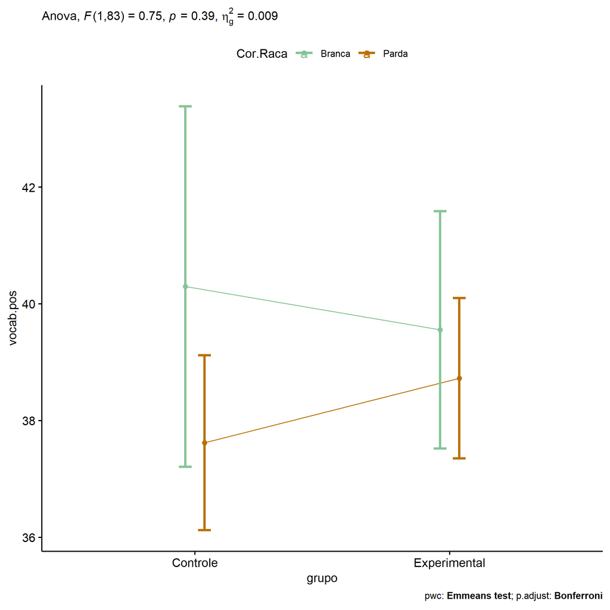

```r
if (!is.null(plots[["grupo"]]))
  plots[["grupo"]] + ggplot2::scale_color_manual(values = color[["Cor.Raca"]])
```

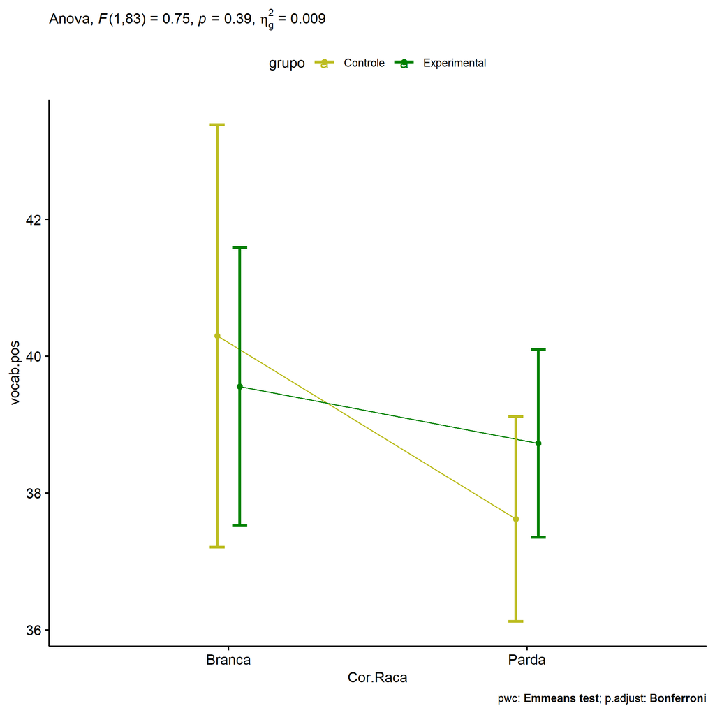

```r
if (!is.null(plots[["Cor.Raca"]]))
  plots[["Cor.Raca"]] + ggplot2::scale_color_manual(values = color[["grupo"]])
```

```r
plots <- twoWayAncovaBoxPlots(
  wdat, "vocab.pos", c("grupo","Cor.Raca"), aov, pwcs, covar = "vocab.pre",
  theme = "classic", color = color[["grupo:Cor.Raca"]],
  subtitle = which(aov$Effect == "grupo:Cor.Raca"))
```

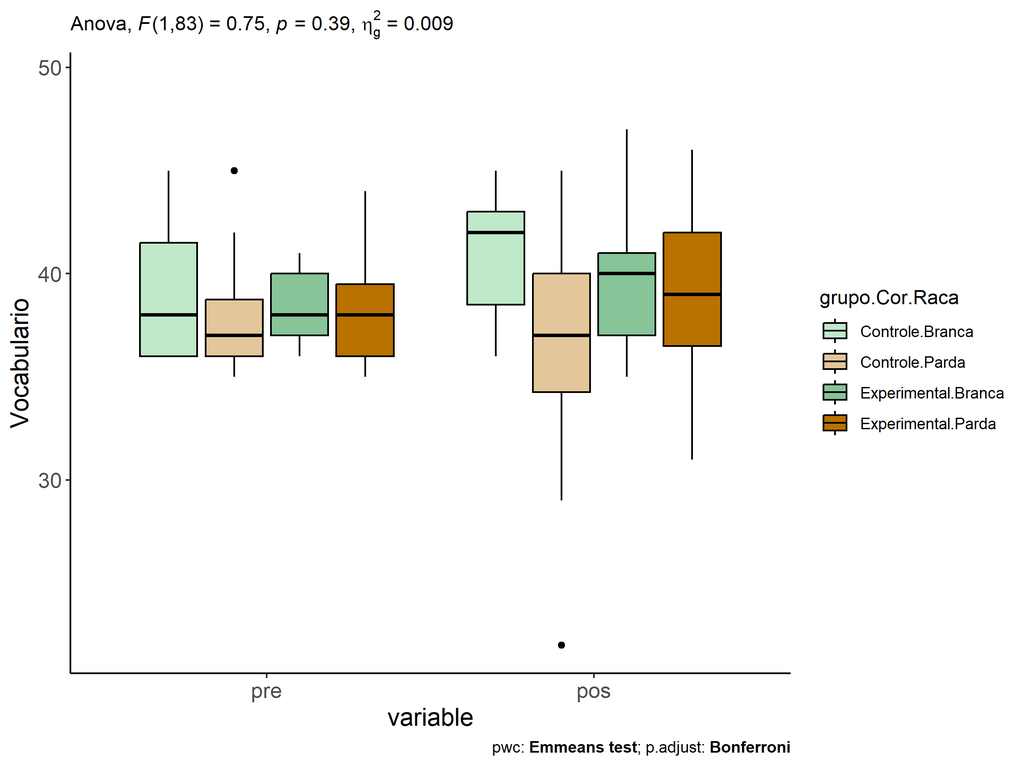

```r
plots[["grupo:Cor.Raca"]] + ggplot2::ylab("Vocabulario") + ggplot2::scale_x_discrete(labels=c('pre', 'pos'))
```

```r
plots <- twoWayAncovaBoxPlots(
  wdat.long, "vocab", c("grupo","Cor.Raca"), aov, pwc.long, pre.post = "time",
  theme = "classic", color = color$prepost)
```

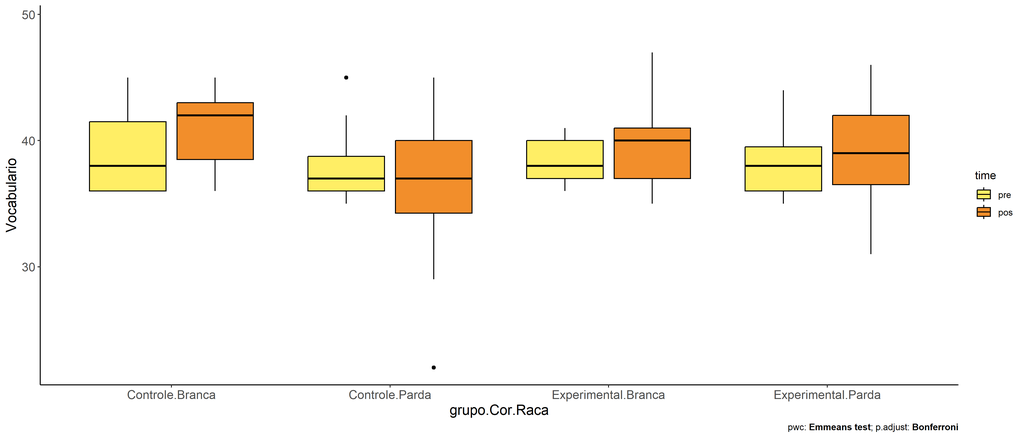

```r
plots[["grupo:Cor.Raca"]] + ggplot2::ylab("Vocabulario")
```

### Checking linearity assumption

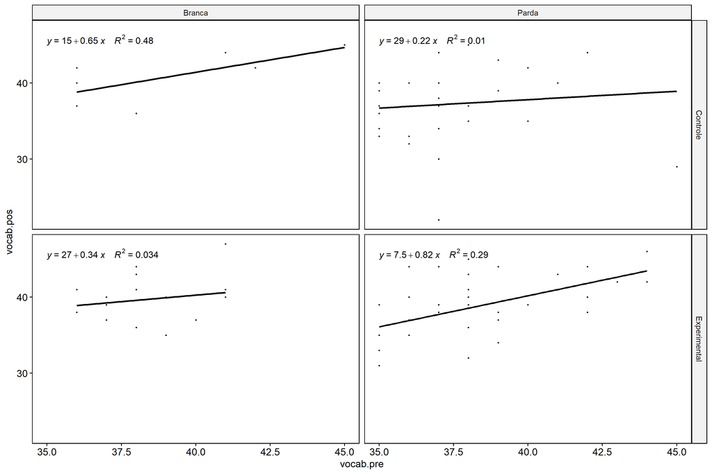

```r
ggscatter(wdat, x = "vocab.pre", y = "vocab.pos", size = 0.5,
          facet.by = c("grupo","Cor.Raca"), add = "reg.line")+
  stat_regline_equation(
    aes(label =  paste(..eq.label.., ..rr.label.., sep = "~~~~"))
  )
```

### Checking normality and homogeneity

```r
res <- augment(lm(vocab.pos ~ vocab.pre + grupo*Cor.Raca, data = wdat))
```

```r
shapiro_test(res$.resid)
```

```
## # A tibble: 1 × 3
##   variable   statistic p.value
##   <chr>          <dbl>   <dbl>
## 1 res$.resid     0.959 0.00742
```

```r
levene_test(res, .resid ~ grupo*Cor.Raca)
```

```
## # A tibble: 1 × 4
##     df1   df2 statistic     p
##   <int> <int>     <dbl> <dbl>
## 1     3    84      1.72 0.170
```

# ANCOVA and Pairwise for two factors **grupo:Serie**

## Without remove non-normal data

```r
pdat = remove_group_data(dat[!is.na(dat[["grupo"]]) & !is.na(dat[["Serie"]]),], "vocab.pos", c("grupo","Serie"))

pdat.long <- rbind(pdat[,c("id","grupo","Serie")], pdat[,c("id","grupo","Serie")])
pdat.long[["time"]] <- c(rep("pre", nrow(pdat)), rep("pos", nrow(pdat)))
pdat.long[["time"]] <- factor(pdat.long[["time"]], c("pre","pos"))
pdat.long[["vocab"]] <- c(pdat[["vocab.pre"]], pdat[["vocab.pos"]])

aov = anova_test(pdat, vocab.pos ~ vocab.pre + grupo*Serie)
laov[["grupo:Serie"]] <- get_anova_table(aov)
```

```r
pwcs <- list()
pwcs[["Serie"]] <- emmeans_test(
  group_by(pdat, grupo), vocab.pos ~ Serie,
  covariate = vocab.pre, p.adjust.method = "bonferroni")
pwcs[["grupo"]] <- emmeans_test(
  group_by(pdat, Serie), vocab.pos ~ grupo,
  covariate = vocab.pre, p.adjust.method = "bonferroni")

pwc <- plyr::rbind.fill(pwcs[["grupo"]], pwcs[["Serie"]])
pwc <- pwc[,c("grupo","Serie", colnames(pwc)[!colnames(pwc) %in% c("grupo","Serie")])]
```

```r
pwc.long <- emmeans_test(dplyr::group_by_at(pdat.long, c("grupo","Serie")),
                         vocab ~ time,
                         p.adjust.method = "bonferroni")
lpwc[["grupo:Serie"]] <- plyr::rbind.fill(pwc, pwc.long)
```

```r
ds <- get.descriptives(pdat, "vocab.pos", c("grupo","Serie"), covar = "vocab.pre")
ds <- merge(ds[ds$variable != "vocab.pre",],
            ds[ds$variable == "vocab.pre", !colnames(ds) %in% c("variable")],
            by = c("grupo","Serie"), all.x = T, suffixes = c("", ".vocab.pre"))
ds <- merge(get_emmeans(pwcs[["grupo"]]), ds, by = c("grupo","Serie"), suffixes = c(".emms", ""))
ds <- ds[,c("grupo","Serie","n","mean.vocab.pre","se.vocab.pre","mean","se","emmean","se.emms")]

colnames(ds) <- c("grupo","Serie", "N", paste0(c("M","SE")," (pre)"),
                  paste0(c("M","SE"), " (unadj)"), paste0(c("M", "SE"), " (adj)"))

lemms[["grupo:Serie"]] <- ds
```

## Computing ANCOVA and PairWise After removing non-normal data (OK)

```r
wdat = pdat

res = residuals(lm(vocab.pos ~ vocab.pre + grupo*Serie, data = wdat))
non.normal = getNonNormal(res, wdat$id, plimit = 0.05)

wdat = wdat[!wdat$id %in% non.normal,]

wdat.long <- rbind(wdat[,c("id","grupo","Serie")], wdat[,c("id","grupo","Serie")])
wdat.long[["time"]] <- c(rep("pre", nrow(wdat)), rep("pos", nrow(wdat)))
wdat.long[["time"]] <- factor(wdat.long[["time"]], c("pre","pos"))
wdat.long[["vocab"]] <- c(wdat[["vocab.pre"]], wdat[["vocab.pos"]])


ldat[["grupo:Serie"]] = wdat

(non.normal)
```

```
##  [1] "P1003" "P2207" "P983"  "P2232" "P3654" "P1966" "P2245" "P996"  "P976"  "P2861" "P3228" "P916"  "P1865"
## [14] "P2394" "P2296"
```

```r
aov = anova_test(wdat, vocab.pos ~ vocab.pre + grupo*Serie)
laov[["grupo:Serie"]] <- merge(get_anova_table(aov), laov[["grupo:Serie"]], by="Effect", suffixes = c("","'"))

(df = get_anova_table(aov))
```

```
## ANOVA Table (type II tests)
##
##        Effect DFn DFd      F        p p<.05      ges
## 1   vocab.pre   1 246 45.512 1.08e-10     * 0.156000
## 2       grupo   1 246  0.195 6.59e-01       0.000793
## 3       Serie   3 246  1.461 2.26e-01       0.018000
## 4 grupo:Serie   3 246  0.155 9.27e-01       0.002000
```

| Effect | DFn | DFd | F | p | p<.05 | ges |
| --- | --- | --- | --- | --- | --- | --- |
| vocab.pre | 1 | 246 | 45.512 | 0.000 | * | 0.156 |
| grupo | 1 | 246 | 0.195 | 0.659 |  | 0.001 |
| Serie | 3 | 246 | 1.461 | 0.226 |  | 0.018 |
| grupo:Serie | 3 | 246 | 0.155 | 0.927 |  | 0.002 |

```r
pwcs <- list()
pwcs[["Serie"]] <- emmeans_test(
  group_by(wdat, grupo), vocab.pos ~ Serie,
  covariate = vocab.pre, p.adjust.method = "bonferroni")
pwcs[["grupo"]] <- emmeans_test(
  group_by(wdat, Serie), vocab.pos ~ grupo,
  covariate = vocab.pre, p.adjust.method = "bonferroni")

pwc <- plyr::rbind.fill(pwcs[["grupo"]], pwcs[["Serie"]])
pwc <- pwc[,c("grupo","Serie", colnames(pwc)[!colnames(pwc) %in% c("grupo","Serie")])]
```

| grupo | Serie | term | .y. | group1 | group2 | df | statistic | p | p.adj | p.adj.signif |
| --- | --- | --- | --- | --- | --- | --- | --- | --- | --- | --- |
|  | 6 ano | vocab.pre*grupo | vocab.pos | Controle | Experimental | 246 | -0.739 | 0.461 | 0.461 | ns |
|  | 7 ano | vocab.pre*grupo | vocab.pos | Controle | Experimental | 246 | 0.116 | 0.908 | 0.908 | ns |
|  | 8 ano | vocab.pre*grupo | vocab.pos | Controle | Experimental | 246 | -0.070 | 0.944 | 0.944 | ns |
|  | 9 ano | vocab.pre*grupo | vocab.pos | Controle | Experimental | 246 | -0.308 | 0.758 | 0.758 | ns |
| Controle |  | vocab.pre*Serie | vocab.pos | 6 ano | 7 ano | 246 | 0.207 | 0.836 | 1.000 | ns |
| Controle |  | vocab.pre*Serie | vocab.pos | 6 ano | 8 ano | 246 | -0.628 | 0.531 | 1.000 | ns |
| Controle |  | vocab.pre*Serie | vocab.pos | 6 ano | 9 ano | 246 | -0.634 | 0.527 | 1.000 | ns |
| Controle |  | vocab.pre*Serie | vocab.pos | 7 ano | 8 ano | 246 | -0.940 | 0.348 | 1.000 | ns |
| Controle |  | vocab.pre*Serie | vocab.pos | 7 ano | 9 ano | 246 | -1.037 | 0.301 | 1.000 | ns |
| Controle |  | vocab.pre*Serie | vocab.pos | 8 ano | 9 ano | 246 | 0.105 | 0.917 | 1.000 | ns |
| Experimental |  | vocab.pre*Serie | vocab.pos | 6 ano | 7 ano | 246 | 1.241 | 0.216 | 1.000 | ns |
| Experimental |  | vocab.pre*Serie | vocab.pos | 6 ano | 8 ano | 246 | 0.094 | 0.925 | 1.000 | ns |
| Experimental |  | vocab.pre*Serie | vocab.pos | 6 ano | 9 ano | 246 | 0.053 | 0.957 | 1.000 | ns |
| Experimental |  | vocab.pre*Serie | vocab.pos | 7 ano | 8 ano | 246 | -1.558 | 0.120 | 0.723 | ns |
| Experimental |  | vocab.pre*Serie | vocab.pos | 7 ano | 9 ano | 246 | -1.668 | 0.097 | 0.580 | ns |
| Experimental |  | vocab.pre*Serie | vocab.pos | 8 ano | 9 ano | 246 | -0.061 | 0.951 | 1.000 | ns |

```r
pwc.long <- emmeans_test(dplyr::group_by_at(wdat.long, c("grupo","Serie")),
                         vocab ~ time,
                         p.adjust.method = "bonferroni")
lpwc[["grupo:Serie"]] <- merge(plyr::rbind.fill(pwc, pwc.long), lpwc[["grupo:Serie"]], by=c("grupo","Serie","term",".y.","group1","group2"), suffixes = c("","'"))
```

| grupo | Serie | term | .y. | group1 | group2 | df | statistic | p | p.adj | p.adj.signif |
| --- | --- | --- | --- | --- | --- | --- | --- | --- | --- | --- |
| Controle | 6 ano | time | vocab | pre | pos | 494 | 0.058 | 0.954 | 0.954 | ns |
| Controle | 7 ano | time | vocab | pre | pos | 494 | 0.545 | 0.586 | 0.586 | ns |
| Controle | 8 ano | time | vocab | pre | pos | 494 | -0.245 | 0.807 | 0.807 | ns |
| Controle | 9 ano | time | vocab | pre | pos | 494 | -0.030 | 0.976 | 0.976 | ns |
| Experimental | 6 ano | time | vocab | pre | pos | 494 | -0.728 | 0.467 | 0.467 | ns |
| Experimental | 7 ano | time | vocab | pre | pos | 494 | 1.140 | 0.255 | 0.255 | ns |
| Experimental | 8 ano | time | vocab | pre | pos | 494 | -0.713 | 0.476 | 0.476 | ns |
| Experimental | 9 ano | time | vocab | pre | pos | 494 | -0.433 | 0.665 | 0.665 | ns |

```r
ds <- get.descriptives(wdat, "vocab.pos", c("grupo","Serie"), covar = "vocab.pre")
ds <- merge(ds[ds$variable != "vocab.pre",],
            ds[ds$variable == "vocab.pre", !colnames(ds) %in% c("variable")],
            by = c("grupo","Serie"), all.x = T, suffixes = c("", ".vocab.pre"))
ds <- merge(get_emmeans(pwcs[["grupo"]]), ds, by = c("grupo","Serie"), suffixes = c(".emms", ""))
ds <- ds[,c("grupo","Serie","n","mean.vocab.pre","se.vocab.pre","mean","se","emmean","se.emms")]

colnames(ds) <- c("grupo","Serie", "N", paste0(c("M","SE")," (pre)"),
                  paste0(c("M","SE"), " (unadj)"), paste0(c("M", "SE"), " (adj)"))

lemms[["grupo:Serie"]] <- merge(ds, lemms[["grupo:Serie"]], by=c("grupo","Serie"), suffixes = c("","'"))
```

| grupo | Serie | N | M (pre) | SE (pre) | M (unadj) | SE (unadj) | M (adj) | SE (adj) |
| --- | --- | --- | --- | --- | --- | --- | --- | --- |
| Controle | 6 ano | 13 | 37.000 | 0.519 | 36.923 | 0.571 | 37.632 | 1.036 |
| Controle | 7 ano | 21 | 37.571 | 0.524 | 37.000 | 0.799 | 37.360 | 0.813 |
| Controle | 8 ano | 18 | 38.278 | 0.758 | 38.556 | 1.127 | 38.484 | 0.876 |
| Controle | 9 ano | 47 | 38.660 | 0.395 | 38.681 | 0.645 | 38.376 | 0.544 |
| Experimental | 6 ano | 16 | 37.188 | 0.518 | 38.062 | 1.142 | 38.657 | 0.933 |
| Experimental | 7 ano | 32 | 38.281 | 0.424 | 37.312 | 0.670 | 37.239 | 0.657 |
| Experimental | 8 ano | 49 | 37.918 | 0.331 | 38.408 | 0.494 | 38.556 | 0.531 |
| Experimental | 9 ano | 59 | 38.593 | 0.388 | 38.864 | 0.564 | 38.600 | 0.485 |

### Plots for ancova

```r
plots <- twoWayAncovaPlots(
  wdat, "vocab.pos", c("grupo","Serie"), aov, pwcs, addParam = c("mean_se"),
  font.label.size=10, step.increase=0.05, p.label="p.adj",
  subtitle = which(aov$Effect == "grupo:Serie"))
```

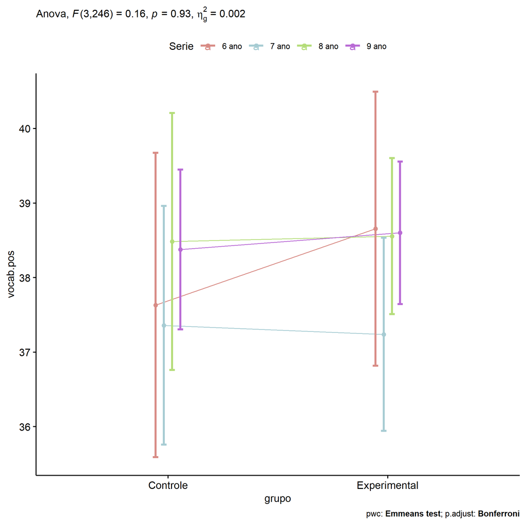

```r
if (!is.null(plots[["grupo"]]))
  plots[["grupo"]] + ggplot2::scale_color_manual(values = color[["Serie"]])
```

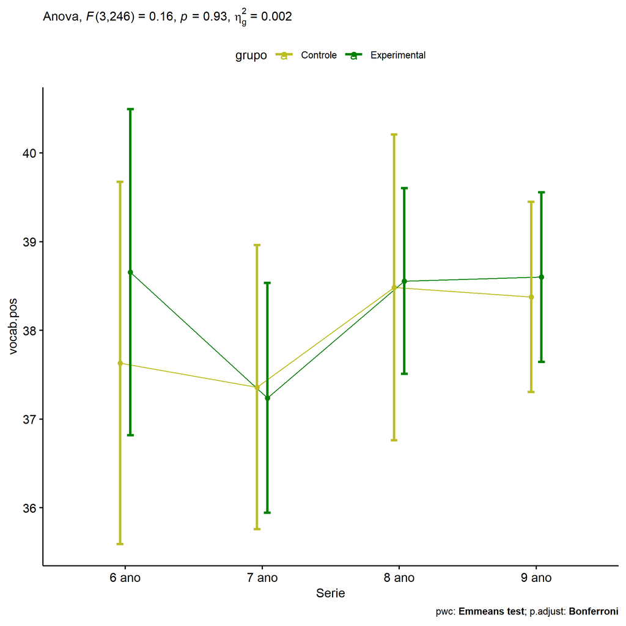

```r
if (!is.null(plots[["Serie"]]))
  plots[["Serie"]] + ggplot2::scale_color_manual(values = color[["grupo"]])
```

```r
plots <- twoWayAncovaBoxPlots(
  wdat, "vocab.pos", c("grupo","Serie"), aov, pwcs, covar = "vocab.pre",
  theme = "classic", color = color[["grupo:Serie"]],
  subtitle = which(aov$Effect == "grupo:Serie"))
```

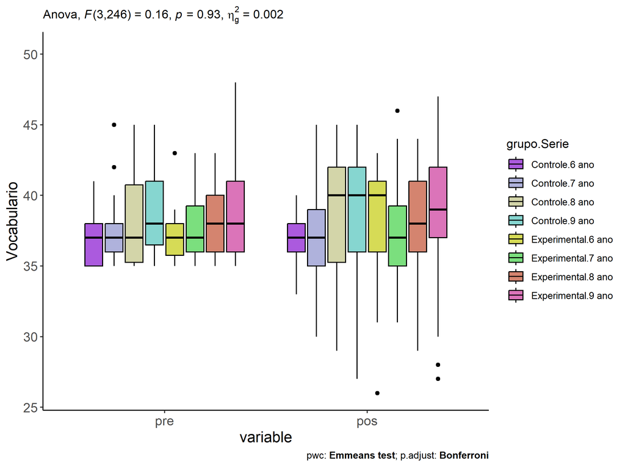

```r
plots[["grupo:Serie"]] + ggplot2::ylab("Vocabulario") + ggplot2::scale_x_discrete(labels=c('pre', 'pos'))
```

```r
plots <- twoWayAncovaBoxPlots(
  wdat.long, "vocab", c("grupo","Serie"), aov, pwc.long, pre.post = "time",
  theme = "classic", color = color$prepost)
```

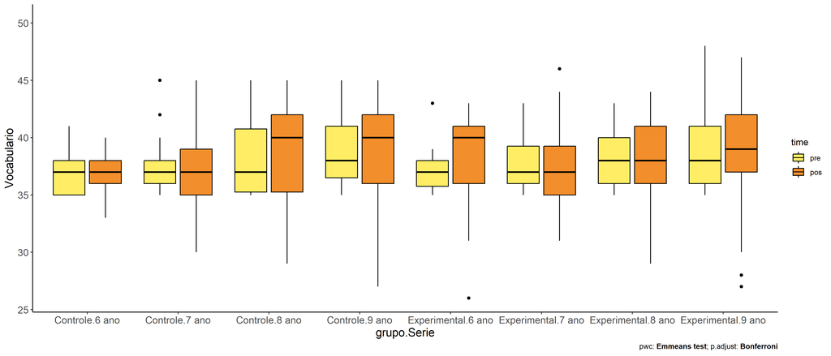

```r
plots[["grupo:Serie"]] + ggplot2::ylab("Vocabulario")
```

### Checking linearity assumption

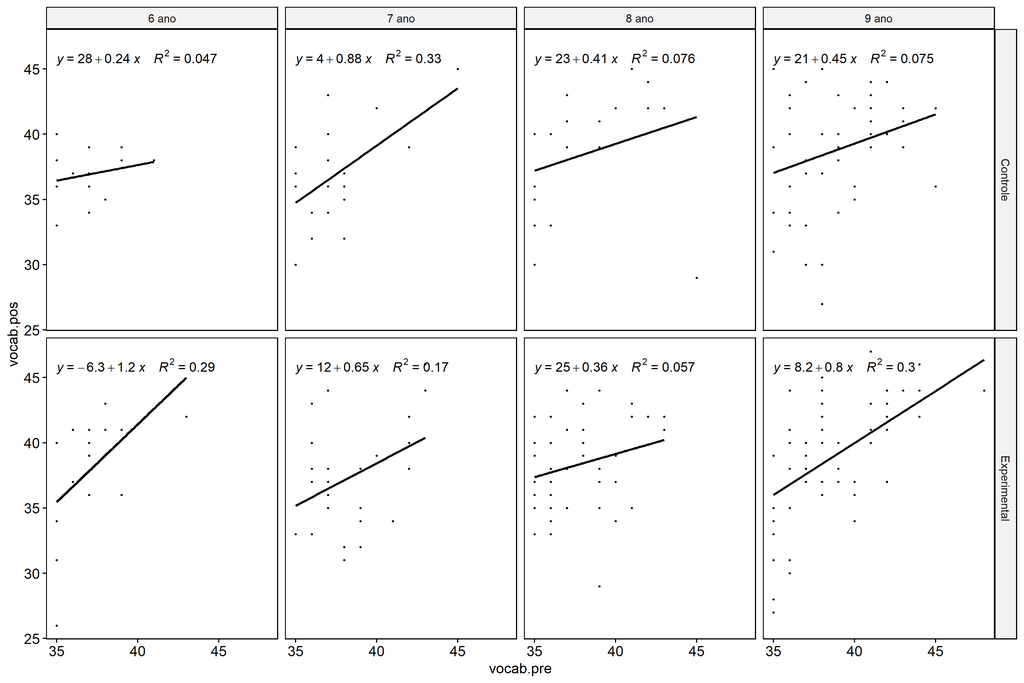

```r
ggscatter(wdat, x = "vocab.pre", y = "vocab.pos", size = 0.5,
          facet.by = c("grupo","Serie"), add = "reg.line")+
  stat_regline_equation(
    aes(label =  paste(..eq.label.., ..rr.label.., sep = "~~~~"))
  )
```

### Checking normality and homogeneity

```r
res <- augment(lm(vocab.pos ~ vocab.pre + grupo*Serie, data = wdat))
```

```r
shapiro_test(res$.resid)
```

```
## # A tibble: 1 × 3
##   variable   statistic p.value
##   <chr>          <dbl>   <dbl>
## 1 res$.resid     0.983 0.00439
```

```r
levene_test(res, .resid ~ grupo*Serie)
```

```
## # A tibble: 1 × 4
##     df1   df2 statistic     p
##   <int> <int>     <dbl> <dbl>
## 1     7   247     0.975 0.450
```

# Summary of Results

## Descriptive Statistics

```r
df <- get.descriptives(ldat[["grupo"]], c(dv.pre, dv.pos), c("grupo"),
                       include.global = T, symmetry.test = T, normality.test = F)
df <- plyr::rbind.fill(
  df, do.call(plyr::rbind.fill, lapply(lfatores2, FUN = function(f) {
    if (nrow(dat) > 0 && sum(!is.na(unique(dat[[f]]))) > 1)
      get.descriptives(ldat[[paste0("grupo:",f)]], c(dv.pre,dv.pos), c("grupo", f),
                       symmetry.test = T, normality.test = F)
    }))
)
(df <- df[,c(fatores1[fatores1 %in% colnames(df)],"variable",
             colnames(df)[!colnames(df) %in% c(fatores1,"variable")])])
```

```
##           grupo Sexo   Zona Cor.Raca Serie  variable   n   mean median min max    sd    se    ci  iqr symmetry
## 1      Controle <NA>   <NA>     <NA>  <NA> vocab.pre  99 38.111   37.0  35  45 2.622 0.264 0.523 4.00       NO
## 2  Experimental <NA>   <NA>     <NA>  <NA> vocab.pre 156 38.173   38.0  35  48 2.598 0.208 0.411 4.00       NO
## 3          <NA> <NA>   <NA>     <NA>  <NA> vocab.pre 255 38.149   38.0  35  48 2.602 0.163 0.321 4.00       NO
## 4      Controle <NA>   <NA>     <NA>  <NA> vocab.pos  99 38.071   38.0  27  45 4.126 0.415 0.823 6.00      YES
## 5  Experimental <NA>   <NA>     <NA>  <NA> vocab.pos 156 38.321   38.0  26  47 3.994 0.320 0.632 5.00      YES
## 6          <NA> <NA>   <NA>     <NA>  <NA> vocab.pos 255 38.224   38.0  26  47 4.039 0.253 0.498 5.00      YES
## 7      Controle    F   <NA>     <NA>  <NA> vocab.pre  53 37.736   37.0  35  45 2.419 0.332 0.667 2.00       NO
## 8      Controle    M   <NA>     <NA>  <NA> vocab.pre  46 38.543   39.0  35  45 2.802 0.413 0.832 4.75      YES
## 9  Experimental    F   <NA>     <NA>  <NA> vocab.pre  88 38.159   38.0  35  44 2.430 0.259 0.515 4.00       NO
## 10 Experimental    M   <NA>     <NA>  <NA> vocab.pre  68 38.191   37.5  35  48 2.819 0.342 0.682 4.00       NO
## 11     Controle    F   <NA>     <NA>  <NA> vocab.pos  53 38.321   38.0  30  45 3.604 0.495 0.993 5.00      YES
## 12     Controle    M   <NA>     <NA>  <NA> vocab.pos  46 37.783   38.5  27  45 4.681 0.690 1.390 7.75      YES
## 13 Experimental    F   <NA>     <NA>  <NA> vocab.pos  88 38.511   39.0  26  47 4.174 0.445 0.884 5.25       NO
## 14 Experimental    M   <NA>     <NA>  <NA> vocab.pos  68 38.074   38.0  28  45 3.763 0.456 0.911 6.00      YES
```

[output cut: 79 more lines]

| grupo | Sexo | Zona | Cor.Raca | Serie | variable | n | mean | median | min | max | sd | se | ci | iqr | symmetry | skewness | kurtosis |
| --- | --- | --- | --- | --- | --- | --- | --- | --- | --- | --- | --- | --- | --- | --- | --- | --- | --- |
| Controle |  |  |  |  | vocab.pre | 99 | 38.111 | 37.0 | 35 | 45 | 2.622 | 0.264 | 0.523 | 4.00 | NO | 0.758 | -0.223 |
| Experimental |  |  |  |  | vocab.pre | 156 | 38.173 | 38.0 | 35 | 48 | 2.598 | 0.208 | 0.411 | 4.00 | NO | 0.769 | 0.142 |
|  |  |  |  |  | vocab.pre | 255 | 38.149 | 38.0 | 35 | 48 | 2.602 | 0.163 | 0.321 | 4.00 | NO | 0.769 | 0.021 |
| Controle |  |  |  |  | vocab.pos | 99 | 38.071 | 38.0 | 27 | 45 | 4.126 | 0.415 | 0.823 | 6.00 | YES | -0.354 | -0.508 |
| Experimental |  |  |  |  | vocab.pos | 156 | 38.321 | 38.0 | 26 | 47 | 3.994 | 0.320 | 0.632 | 5.00 | YES | -0.404 | 0.040 |
|  |  |  |  |  | vocab.pos | 255 | 38.224 | 38.0 | 26 | 47 | 4.039 | 0.253 | 0.498 | 5.00 | YES | -0.388 | -0.165 |
| Controle | F |  |  |  | vocab.pre | 53 | 37.736 | 37.0 | 35 | 45 | 2.419 | 0.332 | 0.667 | 2.00 | NO | 1.112 | 0.554 |
| Controle | M |  |  |  | vocab.pre | 46 | 38.543 | 39.0 | 35 | 45 | 2.802 | 0.413 | 0.832 | 4.75 | YES | 0.396 | -0.727 |
| Experimental | F |  |  |  | vocab.pre | 88 | 38.159 | 38.0 | 35 | 44 | 2.430 | 0.259 | 0.515 | 4.00 | NO | 0.558 | -0.681 |
| Experimental | M |  |  |  | vocab.pre | 68 | 38.191 | 37.5 | 35 | 48 | 2.819 | 0.342 | 0.682 | 4.00 | NO | 0.914 | 0.528 |
| Controle | F |  |  |  | vocab.pos | 53 | 38.321 | 38.0 | 30 | 45 | 3.604 | 0.495 | 0.993 | 5.00 | YES | -0.004 | -0.731 |
| Controle | M |  |  |  | vocab.pos | 46 | 37.783 | 38.5 | 27 | 45 | 4.681 | 0.690 | 1.390 | 7.75 | YES | -0.446 | -0.823 |
| Experimental | F |  |  |  | vocab.pos | 88 | 38.511 | 39.0 | 26 | 47 | 4.174 | 0.445 | 0.884 | 5.25 | NO | -0.547 | 0.354 |
| Experimental | M |  |  |  | vocab.pos | 68 | 38.074 | 38.0 | 28 | 45 | 3.763 | 0.456 | 0.911 | 6.00 | YES | -0.186 | -0.629 |
| Controle |  | Rural |  |  | vocab.pre | 41 | 37.415 | 37.0 | 35 | 45 | 2.617 | 0.409 | 0.826 | 4.00 | NO | 1.246 | 1.145 |
| Controle |  | Urbana |  |  | vocab.pre | 27 | 37.704 | 37.0 | 35 | 43 | 2.216 | 0.426 | 0.876 | 2.50 | NO | 0.811 | -0.330 |
| Experimental |  | Rural |  |  | vocab.pre | 51 | 38.333 | 38.0 | 35 | 44 | 2.495 | 0.349 | 0.702 | 3.50 | YES | 0.444 | -0.779 |
| Experimental |  | Urbana |  |  | vocab.pre | 50 | 38.120 | 37.0 | 35 | 48 | 2.811 | 0.398 | 0.799 | 3.00 | NO | 1.230 | 1.345 |
| Controle |  | Rural |  |  | vocab.pos | 41 | 37.976 | 39.0 | 29 | 45 | 4.552 | 0.711 | 1.437 | 7.00 | YES | -0.279 | -0.965 |
| Controle |  | Urbana |  |  | vocab.pos | 27 | 37.852 | 38.0 | 32 | 45 | 3.348 | 0.644 | 1.324 | 3.50 | YES | 0.290 | -0.617 |
| Experimental |  | Rural |  |  | vocab.pos | 51 | 38.824 | 39.0 | 31 | 46 | 3.897 | 0.546 | 1.096 | 6.00 | YES | -0.168 | -0.930 |
| Experimental |  | Urbana |  |  | vocab.pos | 50 | 38.120 | 38.5 | 26 | 46 | 4.129 | 0.584 | 1.173 | 5.00 | NO | -0.750 | 0.588 |
| Controle |  |  | Branca |  | vocab.pre | 7 | 39.143 | 38.0 | 36 | 45 | 3.579 | 1.353 | 3.310 | 5.50 | YES | 0.424 | -1.651 |
| Controle |  |  | Parda |  | vocab.pre | 30 | 37.533 | 37.0 | 35 | 45 | 2.360 | 0.431 | 0.881 | 2.75 | NO | 1.170 | 1.349 |
| Experimental |  |  | Branca |  | vocab.pre | 16 | 38.500 | 38.0 | 36 | 41 | 1.713 | 0.428 | 0.913 | 3.00 | YES | 0.149 | -1.395 |
| Experimental |  |  | Parda |  | vocab.pre | 35 | 38.343 | 38.0 | 35 | 44 | 2.656 | 0.449 | 0.912 | 3.50 | NO | 0.582 | -0.716 |
| Controle |  |  | Branca |  | vocab.pos | 7 | 40.857 | 42.0 | 36 | 45 | 3.388 | 1.280 | 3.133 | 4.50 | YES | -0.248 | -1.727 |
| Controle |  |  | Parda |  | vocab.pos | 30 | 37.267 | 37.0 | 22 | 45 | 5.166 | 0.943 | 1.929 | 5.75 | NO | -0.714 | 0.564 |
| Experimental |  |  | Branca |  | vocab.pos | 16 | 39.750 | 40.0 | 35 | 47 | 3.152 | 0.788 | 1.679 | 4.00 | NO | 0.539 | -0.405 |
| Experimental |  |  | Parda |  | vocab.pos | 35 | 38.829 | 39.0 | 31 | 46 | 4.055 | 0.685 | 1.393 | 5.50 | YES | -0.178 | -0.891 |
| Controle |  |  |  | 6 ano | vocab.pre | 13 | 37.000 | 37.0 | 35 | 41 | 1.871 | 0.519 | 1.131 | 3.00 | NO | 0.564 | -0.777 |
| Controle |  |  |  | 7 ano | vocab.pre | 21 | 37.571 | 37.0 | 35 | 45 | 2.399 | 0.524 | 1.092 | 2.00 | NO | 1.498 | 2.248 |
| Controle |  |  |  | 8 ano | vocab.pre | 18 | 38.278 | 37.0 | 35 | 45 | 3.214 | 0.758 | 1.598 | 5.50 | NO | 0.556 | -1.112 |
| Controle |  |  |  | 9 ano | vocab.pre | 47 | 38.660 | 38.0 | 35 | 45 | 2.705 | 0.395 | 0.794 | 4.50 | NO | 0.541 | -0.600 |
| Experimental |  |  |  | 6 ano | vocab.pre | 16 | 37.188 | 37.0 | 35 | 43 | 2.073 | 0.518 | 1.104 | 2.25 | NO | 1.156 | 1.267 |
| Experimental |  |  |  | 7 ano | vocab.pre | 32 | 38.281 | 37.0 | 35 | 43 | 2.399 | 0.424 | 0.865 | 3.25 | NO | 0.669 | -0.949 |
| Experimental |  |  |  | 8 ano | vocab.pre | 49 | 37.918 | 38.0 | 35 | 43 | 2.317 | 0.331 | 0.666 | 4.00 | YES | 0.412 | -0.948 |
| Experimental |  |  |  | 9 ano | vocab.pre | 59 | 38.593 | 38.0 | 35 | 48 | 2.983 | 0.388 | 0.777 | 5.00 | NO | 0.692 | -0.025 |
| Controle |  |  |  | 6 ano | vocab.pos | 13 | 36.923 | 37.0 | 33 | 40 | 2.060 | 0.571 | 1.245 | 2.00 | YES | -0.381 | -1.053 |
| Controle |  |  |  | 7 ano | vocab.pos | 21 | 37.000 | 37.0 | 30 | 45 | 3.661 | 0.799 | 1.666 | 4.00 | YES | 0.233 | -0.358 |
| Controle |  |  |  | 8 ano | vocab.pos | 18 | 38.556 | 40.0 | 29 | 45 | 4.780 | 1.127 | 2.377 | 6.75 | NO | -0.625 | -0.946 |
| Controle |  |  |  | 9 ano | vocab.pos | 47 | 38.681 | 40.0 | 27 | 45 | 4.419 | 0.645 | 1.297 | 6.00 | NO | -0.633 | -0.410 |
| Experimental |  |  |  | 6 ano | vocab.pos | 16 | 38.062 | 40.0 | 26 | 43 | 4.568 | 1.142 | 2.434 | 5.00 | NO | -1.226 | 0.619 |
| Experimental |  |  |  | 7 ano | vocab.pos | 32 | 37.312 | 37.0 | 31 | 46 | 3.788 | 0.670 | 1.366 | 4.25 | YES | 0.483 | -0.560 |
| Experimental |  |  |  | 8 ano | vocab.pos | 49 | 38.408 | 38.0 | 29 | 44 | 3.458 | 0.494 | 0.993 | 5.00 | YES | -0.217 | -0.561 |
| Experimental |  |  |  | 9 ano | vocab.pos | 59 | 38.864 | 39.0 | 27 | 47 | 4.333 | 0.564 | 1.129 | 5.00 | NO | -0.596 | 0.137 |

## ANCOVA Table Comparison

```r
df <- do.call(plyr::rbind.fill, laov)
(df <- df[!duplicated(df$Effect),])
```

```
##            Effect DFn DFd      F        p p<.05      ges DFn' DFd'     F'       p' p<.05'  ges'
## 1           grupo   1 252  0.196 6.58e-01       0.000778    1  267  2.911 8.90e-02        0.011
## 2       vocab.pre   1 252 53.357 3.65e-12     * 0.175000    1  267 19.983 1.16e-05      * 0.070
## 4      grupo:Sexo   1 250  0.415 5.20e-01       0.002000    1  265  0.381 5.38e-01        0.001
## 5            Sexo   1 250  2.256 1.34e-01       0.009000    1  265  3.660 5.70e-02        0.014
## 8      grupo:Zona   1 164  0.059 8.08e-01       0.000362    1  172  0.280 5.97e-01        0.002
## 10           Zona   1 164  0.629 4.29e-01       0.004000    1  172  0.887 3.48e-01        0.005
## 11       Cor.Raca   1  83  2.070 1.54e-01       0.024000    1   86  2.785 9.90e-02        0.031
## 13 grupo:Cor.Raca   1  83  0.752 3.88e-01       0.009000    1   86  0.897 3.46e-01        0.010
## 16    grupo:Serie   3 246  0.155 9.27e-01       0.002000    3  261  1.113 3.44e-01        0.013
## 17          Serie   3 246  1.461 2.26e-01       0.018000    3  261  2.880 3.60e-02      * 0.032
```

|  | Effect | DFn | DFd | F | p | p<.05 | ges | DFn’ | DFd’ | F’ | p’ | p<.05’ | ges’ |
| --- | --- | --- | --- | --- | --- | --- | --- | --- | --- | --- | --- | --- | --- |
| 1 | grupo | 1 | 252 | 0.196 | 0.658 |  | 0.001 | 1 | 267 | 2.911 | 0.089 |  | 0.011 |
| 2 | vocab.pre | 1 | 252 | 53.357 | 0.000 | * | 0.175 | 1 | 267 | 19.983 | 0.000 | * | 0.070 |
| 4 | grupo:Sexo | 1 | 250 | 0.415 | 0.520 |  | 0.002 | 1 | 265 | 0.381 | 0.538 |  | 0.001 |
| 5 | Sexo | 1 | 250 | 2.256 | 0.134 |  | 0.009 | 1 | 265 | 3.660 | 0.057 |  | 0.014 |
| 8 | grupo:Zona | 1 | 164 | 0.059 | 0.808 |  | 0.000 | 1 | 172 | 0.280 | 0.597 |  | 0.002 |
| 10 | Zona | 1 | 164 | 0.629 | 0.429 |  | 0.004 | 1 | 172 | 0.887 | 0.348 |  | 0.005 |
| 11 | Cor.Raca | 1 | 83 | 2.070 | 0.154 |  | 0.024 | 1 | 86 | 2.785 | 0.099 |  | 0.031 |
| 13 | grupo:Cor.Raca | 1 | 83 | 0.752 | 0.388 |  | 0.009 | 1 | 86 | 0.897 | 0.346 |  | 0.010 |
| 16 | grupo:Serie | 3 | 246 | 0.155 | 0.927 |  | 0.002 | 3 | 261 | 1.113 | 0.344 |  | 0.013 |
| 17 | Serie | 3 | 246 | 1.461 | 0.226 |  | 0.018 | 3 | 261 | 2.880 | 0.036 | * | 0.032 |

## PairWise Table Comparison

```r
df <- do.call(plyr::rbind.fill, lpwc)
df <- df[,c(names(lfatores), names(df)[!names(df) %in% c(names(lfatores),"term",".y.")])]
```

| grupo | Sexo | Zona | Cor.Raca | Serie | group1 | group2 | df | statistic | p | p.adj | p.adj.signif | df’ | statistic’ | p’ | p.adj’ | p.adj.signif’ |
| --- | --- | --- | --- | --- | --- | --- | --- | --- | --- | --- | --- | --- | --- | --- | --- | --- |
| Controle |  |  |  |  | pre | pos | 506 | 0.084 | 0.933 | 0.933 | ns | 536 | 2.805 | 0.005 | 0.005 | ** |
| Experimental |  |  |  |  | pre | pos | 506 | -0.383 | 0.702 | 0.702 | ns | 536 | 1.015 | 0.310 | 0.310 | ns |
|  |  |  |  |  | Controle | Experimental | 252 | -0.443 | 0.658 | 0.658 | ns | 267 | -1.706 | 0.089 | 0.089 | ns |
| Controle | F |  |  |  | pre | pos | 502 | -0.884 | 0.377 | 0.377 | ns | 532 | 0.917 | 0.360 | 0.360 | ns |
| Controle | M |  |  |  | pre | pos | 502 | 1.071 | 0.285 | 0.285 | ns | 532 | 3.118 | 0.002 | 0.002 | ** |
| Controle |  |  |  |  | F | M | 250 | 1.440 | 0.151 | 0.151 | ns | 265 | 1.690 | 0.092 | 0.092 | ns |
| Experimental | F |  |  |  | pre | pos | 502 | -0.686 | 0.493 | 0.493 | ns | 532 | 0.127 | 0.899 | 0.899 | ns |
| Experimental | M |  |  |  | pre | pos | 502 | 0.201 | 0.841 | 0.841 | ns | 532 | 1.383 | 0.167 | 0.167 | ns |
| Experimental |  |  |  |  | F | M | 250 | 0.773 | 0.440 | 0.440 | ns | 265 | 1.089 | 0.277 | 0.277 | ns |
|  | F |  |  |  | Controle | Experimental | 250 | 0.139 | 0.889 | 0.889 | ns | 265 | -0.799 | 0.425 | 0.425 | ns |
|  | M |  |  |  | Controle | Experimental | 250 | -0.745 | 0.457 | 0.457 | ns | 265 | -1.580 | 0.115 | 0.115 | ns |
| Controle |  |  |  |  | Rural | Urbana | 164 | 0.306 | 0.760 | 0.760 | ns | 172 | -0.175 | 0.861 | 0.861 | ns |
| Controle |  | Rural |  |  | pre | pos | 330 | -0.747 | 0.456 | 0.456 | ns | 346 | 0.553 | 0.580 | 0.580 | ns |
| Controle |  | Urbana |  |  | pre | pos | 330 | -0.160 | 0.873 | 0.873 | ns | 346 | 0.328 | 0.743 | 0.743 | ns |
| Experimental |  |  |  |  | Rural | Urbana | 164 | 0.771 | 0.442 | 0.442 | ns | 172 | -1.066 | 0.288 | 0.288 | ns |
| Experimental |  | Rural |  |  | pre | pos | 330 | -0.728 | 0.467 | 0.467 | ns | 346 | 1.475 | 0.141 | 0.141 | ns |
| Experimental |  | Urbana |  |  | pre | pos | 330 | 0.000 | 1.000 | 1.000 | ns | 346 | 0.000 | 1.000 | 1.000 | ns |
|  |  | Rural |  |  | Controle | Experimental | 164 | -0.406 | 0.685 | 0.685 | ns | 172 | 0.290 | 0.772 | 0.772 | ns |
|  |  | Urbana |  |  | Controle | Experimental | 164 | -0.035 | 0.972 | 0.972 | ns | 172 | -0.447 | 0.655 | 0.655 | ns |
| Controle |  |  | Branca |  | pre | pos | 168 | -0.913 | 0.363 | 0.363 | ns | 174 | -0.706 | 0.481 | 0.481 | ns |
| Controle |  |  |  |  | Branca | Parda | 83 | 1.540 | 0.127 | 0.127 | ns | 86 | 1.741 | 0.085 | 0.085 | ns |
| Controle |  |  | Parda |  | pre | pos | 168 | 0.294 | 0.769 | 0.769 | ns | 174 | 1.596 | 0.112 | 0.112 | ns |
| Experimental |  |  | Branca |  | pre | pos | 168 | -1.007 | 0.316 | 0.316 | ns | 174 | -0.778 | 0.437 | 0.437 | ns |
| Experimental |  |  |  |  | Branca | Parda | 83 | 0.676 | 0.501 | 0.501 | ns | 86 | 0.816 | 0.417 | 0.417 | ns |
| Experimental |  |  | Parda |  | pre | pos | 168 | -0.578 | 0.564 | 0.564 | ns | 174 | 0.078 | 0.938 | 0.938 | ns |
|  |  |  | Branca |  | Controle | Experimental | 83 | 0.400 | 0.690 | 0.690 | ns | 86 | 0.298 | 0.767 | 0.767 | ns |
|  |  |  | Parda |  | Controle | Experimental | 83 | -1.074 | 0.286 | 0.286 | ns | 86 | -1.450 | 0.151 | 0.151 | ns |
| Controle |  |  |  | 6 ano | pre | pos | 494 | 0.058 | 0.954 | 0.954 | ns | 524 | 0.042 | 0.966 | 0.966 | ns |
| Controle |  |  |  | 7 ano | pre | pos | 494 | 0.545 | 0.586 | 0.586 | ns | 524 | 1.842 | 0.066 | 0.066 | ns |
| Controle |  |  |  | 8 ano | pre | pos | 494 | -0.245 | 0.807 | 0.807 | ns | 524 | 3.020 | 0.003 | 0.003 | ** |
| Controle |  |  |  | 9 ano | pre | pos | 494 | -0.030 | 0.976 | 0.976 | ns | 524 | 0.905 | 0.366 | 0.366 | ns |
| Controle |  |  |  |  | 6 ano | 7 ano | 246 | 0.207 | 0.836 | 1.000 | ns | 261 | 1.071 | 0.285 | 1.000 | ns |
| Controle |  |  |  |  | 6 ano | 8 ano | 246 | -0.628 | 0.531 | 1.000 | ns | 261 | 1.804 | 0.072 | 0.434 | ns |
| Controle |  |  |  |  | 6 ano | 9 ano | 246 | -0.634 | 0.527 | 1.000 | ns | 261 | 0.017 | 0.987 | 1.000 | ns |
| Controle |  |  |  |  | 7 ano | 8 ano | 246 | -0.940 | 0.348 | 1.000 | ns | 261 | 0.874 | 0.383 | 1.000 | ns |
| Controle |  |  |  |  | 7 ano | 9 ano | 246 | -1.037 | 0.301 | 1.000 | ns | 261 | -1.448 | 0.149 | 0.893 | ns |
| Controle |  |  |  |  | 8 ano | 9 ano | 246 | 0.105 | 0.917 | 1.000 | ns | 261 | -2.448 | 0.015 | 0.090 | ns |
| Experimental |  |  |  | 6 ano | pre | pos | 494 | -0.728 | 0.467 | 0.467 | ns | 524 | 0.000 | 1.000 | 1.000 | ns |
| Experimental |  |  |  | 7 ano | pre | pos | 494 | 1.140 | 0.255 | 0.255 | ns | 524 | 2.085 | 0.038 | 0.038 | * |
| Experimental |  |  |  | 8 ano | pre | pos | 494 | -0.713 | 0.476 | 0.476 | ns | 524 | 0.448 | 0.654 | 0.654 | ns |
| Experimental |  |  |  | 9 ano | pre | pos | 494 | -0.433 | 0.665 | 0.665 | ns | 524 | -0.317 | 0.751 | 0.751 | ns |
| Experimental |  |  |  |  | 6 ano | 7 ano | 246 | 1.241 | 0.216 | 1.000 | ns | 261 | 1.055 | 0.292 | 1.000 | ns |
| Experimental |  |  |  |  | 6 ano | 8 ano | 246 | 0.094 | 0.925 | 1.000 | ns | 261 | 0.025 | 0.980 | 1.000 | ns |
| Experimental |  |  |  |  | 6 ano | 9 ano | 246 | 0.053 | 0.957 | 1.000 | ns | 261 | -0.556 | 0.579 | 1.000 | ns |
| Experimental |  |  |  |  | 7 ano | 8 ano | 246 | -1.558 | 0.120 | 0.723 | ns | 261 | -1.395 | 0.164 | 0.984 | ns |
| Experimental |  |  |  |  | 7 ano | 9 ano | 246 | -1.668 | 0.097 | 0.580 | ns | 261 | -2.190 | 0.029 | 0.176 | ns |
| Experimental |  |  |  |  | 8 ano | 9 ano | 246 | -0.061 | 0.951 | 1.000 | ns | 261 | -0.841 | 0.401 | 1.000 | ns |
|  |  |  |  | 6 ano | Controle | Experimental | 246 | -0.739 | 0.461 | 0.461 | ns | 261 | -0.047 | 0.963 | 0.963 | ns |
|  |  |  |  | 7 ano | Controle | Experimental | 246 | 0.116 | 0.908 | 0.908 | ns | 261 | -0.283 | 0.778 | 0.778 | ns |
|  |  |  |  | 8 ano | Controle | Experimental | 246 | -0.070 | 0.944 | 0.944 | ns | 261 | -2.521 | 0.012 | 0.012 | * |
|  |  |  |  | 9 ano | Controle | Experimental | 246 | -0.308 | 0.758 | 0.758 | ns | 261 | -0.920 | 0.359 | 0.359 | ns |

## EMMS Table Comparison

```r
df <- do.call(plyr::rbind.fill, lemms)
df[["N-N'"]] <- df[["N"]] - df[["N'"]]
df <- df[,c(names(lfatores), names(df)[!names(df) %in% names(lfatores)])]
```

| grupo | Sexo | Zona | Cor.Raca | Serie | N | M (pre) | SE (pre) | M (unadj) | SE (unadj) | M (adj) | SE (adj) | N’ | M (pre)’ | SE (pre)’ | M (unadj)’ | SE (unadj)’ | M (adj)’ | SE (adj)’ | N-N’ |
| --- | --- | --- | --- | --- | --- | --- | --- | --- | --- | --- | --- | --- | --- | --- | --- | --- | --- | --- | --- |
| Controle |  |  |  |  | 99 | 38.111 | 0.264 | 38.071 | 0.415 | 38.095 | 0.370 | 108 | 38.185 | 0.258 | 36.389 | 0.688 | 36.377 | 0.569 | -9 |
| Experimental |  |  |  |  | 156 | 38.173 | 0.208 | 38.321 | 0.320 | 38.305 | 0.295 | 162 | 38.154 | 0.202 | 37.623 | 0.419 | 37.631 | 0.465 | -6 |
| Controle | F |  |  |  | 53 | 37.736 | 0.332 | 38.321 | 0.495 | 38.594 | 0.506 | 57 | 37.965 | 0.347 | 37.158 | 0.777 | 37.285 | 0.781 | -4 |
| Controle | M |  |  |  | 46 | 38.543 | 0.413 | 37.783 | 0.690 | 37.522 | 0.543 | 51 | 38.431 | 0.384 | 35.529 | 1.166 | 35.363 | 0.826 | -5 |
| Experimental | F |  |  |  | 88 | 38.159 | 0.259 | 38.511 | 0.445 | 38.505 | 0.392 | 90 | 38.178 | 0.256 | 38.089 | 0.530 | 38.082 | 0.621 | -2 |
| Experimental | M |  |  |  | 68 | 38.191 | 0.342 | 38.074 | 0.456 | 38.046 | 0.446 | 72 | 38.125 | 0.327 | 37.042 | 0.668 | 37.068 | 0.694 | -4 |
| Controle |  | Rural |  |  | 41 | 37.415 | 0.409 | 37.976 | 0.711 | 38.278 | 0.595 | 43 | 37.465 | 0.394 | 36.930 | 1.007 | 37.187 | 0.866 | -2 |
| Controle |  | Urbana |  |  | 27 | 37.704 | 0.426 | 37.852 | 0.644 | 37.990 | 0.730 | 28 | 37.679 | 0.412 | 37.286 | 0.840 | 37.428 | 1.069 | -1 |
| Experimental |  | Rural |  |  | 51 | 38.333 | 0.349 | 38.824 | 0.546 | 38.604 | 0.533 | 56 | 38.286 | 0.329 | 37.036 | 0.923 | 36.852 | 0.758 | -5 |
| Experimental |  | Urbana |  |  | 50 | 38.120 | 0.398 | 38.120 | 0.584 | 38.021 | 0.537 | 50 | 38.120 | 0.398 | 38.120 | 0.584 | 38.025 | 0.800 | 0 |
| Controle |  |  | Branca |  | 7 | 39.143 | 1.353 | 40.857 | 1.280 | 40.298 | 1.552 | 7 | 39.143 | 1.353 | 40.857 | 1.280 | 40.373 | 2.221 | 0 |
| Controle |  |  | Parda |  | 30 | 37.533 | 0.431 | 37.267 | 0.943 | 37.622 | 0.753 | 32 | 37.625 | 0.408 | 35.812 | 1.355 | 36.080 | 1.041 | -2 |
| Experimental |  |  | Branca |  | 16 | 38.500 | 0.428 | 39.750 | 0.788 | 39.556 | 1.022 | 16 | 38.500 | 0.428 | 39.750 | 0.788 | 39.584 | 1.462 | 0 |
| Experimental |  |  | Parda |  | 35 | 38.343 | 0.449 | 38.829 | 0.685 | 38.724 | 0.690 | 36 | 38.306 | 0.438 | 38.222 | 0.901 | 38.153 | 0.974 | -1 |
| Controle |  |  |  | 6 ano | 13 | 37.000 | 0.519 | 36.923 | 0.571 | 37.632 | 1.036 | 13 | 37.000 | 0.519 | 36.923 | 0.571 | 37.610 | 1.630 | 0 |
| Controle |  |  |  | 7 ano | 21 | 37.571 | 0.524 | 37.000 | 0.799 | 37.360 | 0.813 | 23 | 37.652 | 0.489 | 35.130 | 1.509 | 35.433 | 1.222 | -2 |
| Controle |  |  |  | 8 ano | 18 | 38.278 | 0.758 | 38.556 | 1.127 | 38.484 | 0.876 | 22 | 38.091 | 0.644 | 33.864 | 2.375 | 33.908 | 1.247 | -4 |
| Controle |  |  |  | 9 ano | 47 | 38.660 | 0.395 | 38.681 | 0.645 | 38.376 | 0.544 | 50 | 38.780 | 0.388 | 37.940 | 0.744 | 37.579 | 0.832 | -3 |
| Experimental |  |  |  | 6 ano | 16 | 37.188 | 0.518 | 38.062 | 1.142 | 38.657 | 0.933 | 17 | 37.059 | 0.503 | 37.059 | 1.469 | 37.711 | 1.427 | -1 |
| Experimental |  |  |  | 7 ano | 32 | 38.281 | 0.424 | 37.312 | 0.670 | 37.239 | 0.657 | 35 | 38.229 | 0.391 | 35.914 | 1.004 | 35.878 | 0.989 | -3 |
| Experimental |  |  |  | 8 ano | 49 | 37.918 | 0.331 | 38.408 | 0.494 | 38.556 | 0.531 | 51 | 37.961 | 0.324 | 37.549 | 0.766 | 37.670 | 0.820 | -2 |
| Experimental |  |  |  | 9 ano | 59 | 38.593 | 0.388 | 38.864 | 0.564 | 38.600 | 0.485 | 59 | 38.593 | 0.388 | 38.864 | 0.564 | 38.613 | 0.764 | 0 |